# Ellis et al. 2023 Meta-analysis R Code

Lauren Ellis

This R Markdown file presents the annotated R code for the statistical analysis underlying Ellis et al. (2023). Adult Organophosphate and Carbamate Insecticide Exposure and Sperm Concentration: A Systematic Review and Meta-Analysis of the Epidemiological Evidence.

# I. Set Up

## A. Load packages

```r
library(tidyverse)
library(metafor)
library(clubSandwich)
library(dmetar)
library(readxl)
library(writexl)
```

## B. Check R and meta-analysis package versions

```r
R.version
```

```
##                _
## platform       aarch64-apple-darwin20
## arch           aarch64
## os             darwin20
## system         aarch64, darwin20
## status
## major          4
## minor          2.2
## year           2022
## month          10
## day            31
## svn rev        83211
## language       R
## version.string R version 4.2.2 (2022-10-31)
## nickname       Innocent and Trusting
```

```r
packageVersion('metafor')
```

```
## [1] '3.8.1'
```

```r
packageVersion('clubSandwich')
```

```
## [1] '0.5.8'
```

```r
packageVersion('dmetar')
```

```
## [1] '0.0.9000'
```

R versions as of date of submission (12/31/2022):

- R version 4.2.2 (2022-10-31) “Innocent and Trusting”
- RStudio 2022.07.2+576 “Spotted Wakerobin” (from “About RStudio”)

Meta-analysis package versions as of date of submission (12/31/2022):

- ‘metafor’ - V. ‘3.8.1’
- ‘clubSandwich’ - V. ‘0.5.8’
- ‘dmetar’ - V. ‘0.0.9000’

## C. Load extracted results data

Note: Extracted results data can be downloaded on GitHub: https://github.com/Lauren-Ellis/Ellis-et-al.-2023-OP-NMC-Insecticides-and-Sperm-Concentration

```r
OPNMC_data <- read_excel("Ellis-et-al-2023-study-results-data.xlsx",
                          sheet = "Results Data")
OPNMC_data
```

```
## # A tibble: 42 × 60
##    Study   ES_ID Study…¹ Study…² Country Recru…³ AbsTi…⁴ MedRi…⁵ CoExp…⁶ Expos…⁷
##    <chr>   <dbl>   <dbl>   <dbl> <chr>   <chr>     <dbl>   <dbl>   <dbl> <chr>
##  1 Dziewi…     1       1       1 Poland  Clinic        1       1       0 Enviro…
##  2 Dziewi…     2       1       1 Poland  Clinic        1       1       0 Enviro…
##  3 Gharfo…     3       2       2 Iran    Popula…       0       1       0 Occupa…
##  4 Hossai…     4       3       3 Malays… Popula…       0       1       0 Occupa…
##  5 Manika…     5       4       4 India   Clinic        0       1       0 Occupa…
##  6 Marmol…     6       5       5 Venezu… Popula…       0       1       0 Occupa…
##  7 Meeker…     7       6       6 USA     Clinic        1       1       0 Enviro…
##  8 Meeker…     8       6       6 USA     Clinic        1       1       0 Enviro…
##  9 Meeker…     9       6       6 USA     Clinic        1       1       0 Enviro…
## 10 Meeker…    10       6       6 USA     Clinic        1       1       0 Enviro…
## # … with 32 more rows, 50 more variables: Exposure_Assessment_Method <chr>,
## #   Insecticide_Class <chr>, Parent_Metabolite <chr>, Comparison_Groups <chr>,
## #   Exposure_Duration_Notes <chr>, Stat_Test <chr>,
## #   Effect_Size_Being_Extracted <chr>, Effect_Size_Rationale <chr>,
## #   Formula_Inputs <chr>, Stat_Inputs <chr>, SA_Imputation <dbl>, SA_Log <dbl>,
## #   SA_Transform <dbl>, Bivar_Multivar <chr>, No_Predictors <dbl>,
## #   Model_Covariates <chr>, N_E <dbl>, Mean_E <dbl>, SD_E <dbl>, N_C <dbl>, …
```

# II. Data Preparation

## A. Effect size calculations and conversions

Process:

1. Filter by “formula input” and create new data set for each type of input
2. Mutate each data set to add a new variable (Cohen’s D, standardized mean difference, SMD) using relevant conversion formulas
3. Merge data sets with shared Cohen’s D variable
4. Compute bias-corrected Hedges’ G from Cohen’s D

Notes on partial effect sizes:

- This meta-analysis pooled unadjusted and partial effect sizes in the same analysis.
- When calculating partial mean difference effect sizes from adjusted measures, it is recommended to use unadjusted group-level standard deviations (SDs) to calculate the pooled SD.
  - If unadjusted SDs are unavailable, it is recommended to use a multiplier — $sqrt(1-R^2)$ — in an attempt to restore the unadjusted pooled SD (remove the effect of model fit).
    - This concept is discussed in the context of ANCOVA models in [Borenstein & Hedges, 2019, Chp. 11](https://www.jstor.org/stable/10.7758/9781610448864) (p. 215-216) and is expanded for applications to linear regression models in [Aloe et al., 2021](https://www.tandfonline.com/doi/abs/10.1080/00220973.2021.1966605).
  - In this meta-analysis:
    - Unadjusted SDs were only available for two adjusted mean difference measures (Padungtod et al. (1999a; 2000) and Yucra et al. (2006)).
    - Model R^2 values were not available for any adjusted mean difference measures.

### 1. Convert mean difference to Cohen’s D

**Unadjusted md/adjusted md/beta-md coefficient to Cohen’s D**

Notes:

- Used methods from [Borenstein & Hedges, 2019, Chp. 11](https://www.jstor.org/stable/10.7758/9781610448864) to convert mean differences (md) into Cohen’s D.
- Unadjusted/adjusted mean differences between two independent groups (including adjusted mean differences from ANCOVA models and beta coefficients from multivariate regression models with a binary exposure variable and continuous outcome variable) and unadjusted/adjusted group-level standard deviations were accepted as inputs.

```r
# Create functions
md2smd <- function(md, sd.e, sd.c, n.e, n.c) {
  md / (sqrt((((n.e - 1) * (sd.e^2)) + ((n.c - 1) * (sd.c^2))) / (n.e + n.c - 2)))
  } # Borenstein & Hedges, 2019; p. 212, Eq. 11.15-11.16

md2smd_var <- function(n.e, n.c, smd) {
  ((n.e + n.c) / (n.e*n.c)) + ((smd^2) / (2*(n.e + n.c)))
} # Borenstein & Hedges, 2019; p. 213, Eq. 11.17

# Apply functions
OPNMC_Data_MD <- OPNMC_data %>%
  filter(Formula_Inputs == "MD-SDs") %>%  # includes unadjusted means, adjusted means, and beta-md coefficients
  mutate(
    Di = md2smd(md = MD, sd.e = SD_E, sd.c = SD_C, n.e = N_E, n.c = N_C),
    D_Vi = md2smd_var(n.e = N_E, n.c = N_C, smd = Di)
  )
```

**T-stat to Cohen’s D**

Notes:

- Used methods from [Borenstein & Hedges, 2019, Chp. 11](https://www.jstor.org/stable/10.7758/9781610448864) and [Aloe et al., 2021](https://www.tandfonline.com/doi/abs/10.1080/00220973.2021.1966605) to convert t-statistics into Cohen’s D.
- t-statistics from an unadjusted/adjusted t-test of differences in group means or multivariate regression models with a binary exposure variable and continuous outcome variable were accepted as inputs.
- Model R^2 values were not available for any adjusted mean difference measures.

Rules for calculating t-statistics (prior to import into R):

- If p-value was available, calculated t-statistic from p-value and degrees of freedom
- If p-value was not available, calculated t-statistic from beta and SE

```r
# Create functions
tstat2smd <- function(t, n.e, n.c) {
  t * (sqrt((n.e + n.c) / (n.e*n.c)))
}

tstat2smd_var <- function(n.e, n.c, smd) {
  (((n.e+n.c) / (n.e*n.c)) + ((smd^2) / (2*(n.e+n.c))))
}

# Apply functions
OPNMC_Data_Tstat_Neg <- OPNMC_data %>%
  filter(Formula_Inputs == "MD-T") %>%
  filter(MD < 0) %>%
  mutate(
    Di = tstat2smd(t = (as.double(T_Stat)), n.e = N_E, n.c = N_C) * -1,
    D_Vi = tstat2smd_var(n.e = N_E, n.c = N_C, smd = Di)
    )

OPNMC_Data_Tstat_Pos <- OPNMC_data %>%
  filter(Formula_Inputs == "MD-T") %>%
  filter(MD > 0) %>%
  mutate(
    Di = tstat2smd(t = (as.double(T_Stat)), n.e = N_E, n.c = N_C),
    D_Vi = tstat2smd_var(n.e = N_E, n.c = N_C, smd = Di)
  )

# Merge data
OPNMC_Data_Tstat <- full_join(OPNMC_Data_Tstat_Neg, OPNMC_Data_Tstat_Pos)
```

[output not shown]

### 2. Convert odds ratio to Cohen’s D

Notes:

- Used methods from [Borenstein & Hedges, 2019, Chp. 11](https://www.jstor.org/stable/10.7758/9781610448864) to convert odds ratios into Cohen’s D.
- Unadjusted/adjusted ORs were accepted as inputs.
- ‘log’ = natural log (ln) in base R

```r
# Create functions
or2smd <- function(or) {
  (log(or) * (sqrt(3))) / pi
} # Borenstein & Hedges, 2019; p. 233, Eq. 11.76

or2smd_var <- function(or.ub, or.lb) {
 ((3 * (((log(or.ub) - log(or.lb)) / 3.92)^2)) / (pi^2))
} # Borenstein & Hedges, 2019; p. 232-233, Table 11.5 & 11.77

# Apply functions
OPNMC_Data_ORTable <- OPNMC_data %>%
  filter(Formula_Inputs == "OR") %>%
  mutate(
    Di = (or2smd(or = OR) * -1), # multiplied by -1 to get correct direction of effect
    D_Vi = ((3 * OR_Vln) / (pi^2))
  )

OPNMC_Data_BetaOR <- OPNMC_data %>%
  filter(Formula_Inputs == "Beta-OR") %>%
  mutate(
    Di = (or2smd(or = OR) * -1), # multiplied by -1 to get correct direction of effect
    D_Vi = or2smd_var(or.ub = OR_UB, or.lb = OR_LB)
  )

# Merge data
OPNMC_Data_OR <- full_join(OPNMC_Data_ORTable, OPNMC_Data_BetaOR)
```

[output not shown]

### 3. Convert correlation to Cohen’s D

**Bivariate correlation to Cohen’s D**

Note: Used methods from [Borenstein & Hedges, 2019, Chp. 11](https://www.jstor.org/stable/10.7758/9781610448864) to convert bivariate correlation coefficients to Cohen’s D.

```r
# Create functions
r_var <- function(r, n){
  ((1-(r^2))^2) / (n-1)
} # Borenstein & Hedges, 2019; p. 220, Eq. 11.35

r2smd <- function(r) {
  (2 * r) / (sqrt(1-(r^2)))
} # Borenstein & Hedges, 2019; p. 234, Eq. 11.80

r2smd_var <- function(r, r.v) {
  (4 * r.v) / ((1-(r^2))^3)
} # Borenstein & Hedges, 2019; p. 234, Rq. 11.81

# Apply functions
OPNMC_Data_R <- OPNMC_data %>%
  filter(Formula_Inputs == "R") %>%
  mutate(
    R_Vi = as.double(r_var(r = R, n = N_Total)),
    Di = as.double(r2smd(r = Abs_R) * -1),  # multiplied by -1 to get correct direction of effect
    D_Vi = as.double(r2smd_var(r = Abs_R, r.v = R_Vi))
    )
```

**Adjusted beta-cont (t-stat) to partial correlation to Cohen’s D**

Notes:

- Used methods from [Aloe et al., 2013](https://www.journals.uchicago.edu/doi/abs/10.5243/jsswr.2013.24) to calculate a partial correlation from homogenized multivariate linear regression beta coefficients (see formulas below)
  - ‘t’ is the statistic of the regression coefficient in the multiple regression model
  - ‘df’ is the degrees of freedom
  - ‘p’ is the number predictors included in the model, including the exposure variable of interest
    - “The only difference between the variances of the bivariate correlation and the partial correlation is the incorporation of ‘p’ in the denominator of the partial correlation.”
  - ‘n’ is the number of study participants

```r
# Create functions
betaconttstat2partialr <- function(t, N_Total, p) {
  t / ((sqrt((t^2)) + (N_Total - p - 1)))
} # Aloe et al., 2013; p. 392, Eq. 2

betaconttstat2partialr_var <- function(r.partial, N_Total, p) {
  ((1 - (r.partial^2))^2) / (N_Total - p - 1)
} # Aloe et al., 2013; p. 392, Eq. 2

# Apply functions
OPNMC_Data_BetaConttstat_Neg <- OPNMC_data %>%
  filter(Formula_Inputs == "Beta-Cont-T") %>%
  filter(BetaCont < 0) %>%
  mutate(
    T_stat = as.double(T_Stat),
    Partial_Ri = as.double(betaconttstat2partialr(t = T_stat, N_Total = N_Total, p = No_Predictors)),
    Partial_R_Vi = as.double(betaconttstat2partialr_var(r.partial = Partial_Ri, N_Total = N_Total,
                                              p = No_Predictors)),
    Di = (2 * Partial_Ri) / (sqrt(1-(Partial_Ri^2))) * -1,  # multiplied by -1 to get correct direction of effect
    D_Vi = (4 * Partial_R_Vi) / ((1-(Partial_Ri^2))^3)
    )

OPNMC_Data_BetaConttstat_Pos <- OPNMC_data %>%
  filter(Formula_Inputs == "Beta-Cont-T") %>%
  filter(BetaCont >= 0) %>%
  mutate(
    T_stat = as.double(T_Stat),
    Partial_Ri = as.double(betaconttstat2partialr(t = T_stat, N_Total = N_Total, p = No_Predictors)),
    Partial_R_Vi = as.double(betaconttstat2partialr_var(r.partial = Partial_Ri, N_Total = N_Total,
                                              p = No_Predictors)),
    Di = (2 * Partial_Ri) / (sqrt(1-(Partial_Ri^2))),
    D_Vi = (4 * Partial_R_Vi) / ((1-(Partial_Ri^2))^3)
  )

# Merge data
OPNMC_Data_BetaContTstat <- full_join(OPNMC_Data_BetaConttstat_Neg, OPNMC_Data_BetaConttstat_Pos)
```

[output not shown]

### 4. Merge calculated Cohen’s D data

```r
# Merge Hedges' G data
OPNMC_Data1 <- full_join(OPNMC_Data_MD, OPNMC_Data_Tstat)
```

[output not shown]

```r
OPNMC_Data2 <- full_join(OPNMC_Data1, OPNMC_Data_OR)
```

[output not shown]

```r
OPNMC_Data3 <- full_join(OPNMC_Data2, OPNMC_Data_R)
```

[output not shown]

```r
OPNMC_Data4 <- full_join(OPNMC_Data3, OPNMC_Data_BetaContTstat)
```

[output not shown]

### 5. Convert Cohen’s D to Hedges’ G

Notes:

```r
# Create functions
smd2hedgesG <- function(smd, N_Total, q, p) {
  smd * (1 - (3 / (4 * ((N_Total - p - 1) - 1) - p)))
}

smd2hedgesG_var <- function(smd.var, N_Total, p) {
  smd.var * ((1 - (3 / (4 * ((N_Total - p - 1) - 1))))^2)
}

# Apply functions
OPNMC_Data_HedgesG <- OPNMC_Data4 %>%
  mutate(
    Gi = smd2hedgesG(smd = Di, N_Total = N_Total, p = No_Predictors),
    G_Vi = smd2hedgesG_var(smd.var = D_Vi, N_Total = N_Total, p = No_Predictors)
  )
OPNMC_Data_HedgesG
```

```
## # A tibble: 42 × 68
##    Study   ES_ID Study…¹ Study…² Country Recru…³ AbsTi…⁴ MedRi…⁵ CoExp…⁶ Expos…⁷
##    <chr>   <dbl>   <dbl>   <dbl> <chr>   <chr>     <dbl>   <dbl>   <dbl> <chr>
##  1 Gharfo…     3       2       2 Iran    Popula…       0       1       0 Occupa…
##  2 Hossai…     4       3       3 Malays… Popula…       0       1       0 Occupa…
##  3 Marmol…     6       5       5 Venezu… Popula…       0       1       0 Occupa…
##  4 Mirand…    17       8       8 Venezu… Popula…       0       1       1 Occupa…
##  5 Multig…    18       9       9 Guadel… Popula…       1       1       0 Occupa…
##  6 Padung…    19      10      10 China   Popula…       0       1       0 Occupa…
##  7 Padung…    20      10      11 China   Popula…       0       1       0 Occupa…
##  8 Padung…    21      10      12 China   Popula…       0       1       0 Occupa…
##  9 Padung…    22      11      13 China   Popula…       1       1       0 Occupa…
## 10 Tan (2…    36      16      18 China   Popula…       0       0       1 Occupa…
## # … with 32 more rows, 58 more variables: Exposure_Assessment_Method <chr>,
## #   Insecticide_Class <chr>, Parent_Metabolite <chr>, Comparison_Groups <chr>,
## #   Exposure_Duration_Notes <chr>, Stat_Test <chr>,
## #   Effect_Size_Being_Extracted <chr>, Effect_Size_Rationale <chr>,
## #   Formula_Inputs <chr>, Stat_Inputs <chr>, SA_Imputation <dbl>, SA_Log <dbl>,
## #   SA_Transform <dbl>, Bivar_Multivar <chr>, No_Predictors <dbl>,
## #   Model_Covariates <chr>, N_E <dbl>, Mean_E <dbl>, SD_E <dbl>, N_C <dbl>, …
```

# III. Descriptive Statistics

## A. Distribution of effect sizes

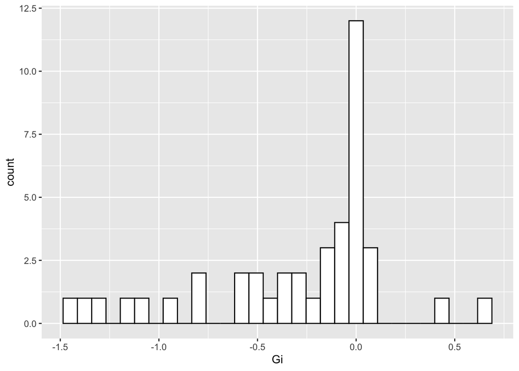

```r
# Histogram of effect sizes
histo1 <- ggplot(OPNMC_Data_HedgesG, aes(x = Gi)) +
            geom_histogram(aes(y = after_stat(count)), colour = "black", fill="white")
histo1
```

```r
# Summary data on study-level effect sizes
OPNMCdatadistro <- OPNMC_Data_HedgesG %>%
  summarise(
    N_studies = length(unique(Study_ID)),
    N_studypops = length(unique(StudyPop_ID)),
    N_effects = length(unique(ES_ID)),
    Gi_Mean = mean(Gi),
    Gi_SD = sd(Gi),
    Gi_Median = median(Gi),
    Gi_Q1 = quantile(Gi, 0.25),
    Gi_Q3 = quantile(Gi, 0.75),
    Gi_Min = min(Gi),
    Gi_Max = max(Gi),
  )
OPNMCdatadistro
```

```
## # A tibble: 1 × 10
##   N_studies N_study…¹ N_eff…² Gi_Mean Gi_SD Gi_Me…³  Gi_Q1   Gi_Q3 Gi_Min Gi_Max
##       <int>     <int>   <int>   <dbl> <dbl>   <dbl>  <dbl>   <dbl>  <dbl>  <dbl>
## 1        20        21      42  -0.295 0.476  -0.114 -0.510 0.00827  -1.44  0.660
## # … with abbreviated variable names ¹N_studypops, ²N_effects, ³Gi_Median
```

```r
# Summary data on study-level effect sizes, by exposure setting
OPNMCdatadistro_expsetting <- OPNMC_Data_HedgesG %>%
  group_by(Exposure_Setting) %>%
  summarize(
    N_effects = length(unique(ES_ID)),
    pct = round((N_effects / nrow(OPNMC_Data_HedgesG) * 100)),
    Gi_Mean = mean(Gi),
    Gi_SD = sd(Gi),
    Gi_Mean = mean(Gi),
    Gi_SD = sd(Gi),
    Gi_Median = median(Gi),
    Gi_Q1 = quantile(Gi, 0.25),
    Gi_Q3 = quantile(Gi, 0.75),
    Gi_Min = min(Gi),
    Gi_Max = max(Gi)
  )
OPNMCdatadistro_expsetting
```

```
## # A tibble: 2 × 10
##   Exposure_Se…¹ N_eff…²   pct Gi_Mean Gi_SD Gi_Me…³  Gi_Q1   Gi_Q3 Gi_Min Gi_Max
##   <chr>           <int> <dbl>   <dbl> <dbl>   <dbl>  <dbl>   <dbl>  <dbl>  <dbl>
## 1 Environmental      23    55  -0.192 0.338 -0.0575 -0.341 0.00515  -1.10  0.414
## 2 Occupational       19    45  -0.421 0.588 -0.270  -0.777 0.00808  -1.44  0.660
## # … with abbreviated variable names ¹Exposure_Setting, ²N_effects, ³Gi_Median
```

## B. Number of unique men included

```r
# No. of effect size estimates and men by study population
OPNMCdatadistro_SampleID <- OPNMC_Data_HedgesG %>%
  group_by(StudyPop_ID) %>%
  summarise(
    N_effects = length(unique(ES_ID)),
    N_men = max(N_Total)
  )
OPNMCdatadistro_SampleID
```

```
## # A tibble: 21 × 3
##    StudyPop_ID N_effects N_men
##          <dbl>     <int> <dbl>
##  1           1         2   315
##  2           2         1    60
##  3           3         1   152
##  4           4         1    10
##  5           5         1    59
##  6           6         4   114
##  7           7         6   116
##  8           8         1    99
##  9           9         1    87
## 10          10         1    17
## # … with 11 more rows
```

```r
Total_Men_Included <- sum(OPNMCdatadistro_SampleID$N_men) # 1,774 unique male participants
```

# IV. Meta-Analysis

## A. Exploring model fit

### 1. Two vs. three levels of random effect

There are two types of dependencies present in the data:

- Correlation dependencies because some effect sizes originate from overlapping study participants and therefore have correlated sampling errors.
  - A correlation of 0.8 was assumed between dependent effect sizes, or effect sizes from the same study populations, unless otherwise noted.
- Hierarchical dependencies because some effect sizes are nested under the same study populations.
  - To explore model fit, we tested whether a three-level model fit the data better than a two-level model
    - The general structure when creating levels of random effect using rma.mv looks like this: ~ 1 | cluster/effects_within_cluster.
  - Levels of random effect:
    - Level 1 = variation in sampling error
    - Level 2 = variation in effect sizes within each cluster (study population)
    - Level 3 = variation between clusters (study populations)

```r
# 2 vs 3 level w/ correlational dependencies
OPNMC_Vmatrix_0.8 <- impute_covariance_matrix(vi = OPNMC_Data_HedgesG$G_Vi,
                                             cluster = OPNMC_Data_HedgesG$StudyPop_ID,
                                             r = 0.8)

OPNMC_MLMA_2levels <- rma.mv(yi = Gi,
                            V = OPNMC_Vmatrix_0.8,
                            data = OPNMC_Data_HedgesG,
                            random = ~ 1 | ES_ID,
                            digits = 2)

OPNMC_MLMA_3levels <- rma.mv(yi = Gi,
                           V = OPNMC_Vmatrix_0.8,
                           data = OPNMC_Data_HedgesG,
                           random = ~ 1 | StudyPop_ID/ES_ID,
                           digits = 2)

anova(OPNMC_MLMA_2levels, OPNMC_MLMA_3levels)
```

```
##
##         df   AIC   BIC  AICc logLik  LRT pval     QE
## Full     3 40.31 45.46 40.96 -17.16           166.36
## Reduced  2 44.03 47.46 44.35 -20.02 5.72 0.02 166.36
```

### 2. Profile likelihood plots for 3-level

Note: When fitting complex, multilevel meta-analytic models, it is important to verify the identifiability of the variance components of the model. (Citation: https://www.metafor-project.org/doku.php/analyses:konstantopoulos2011)

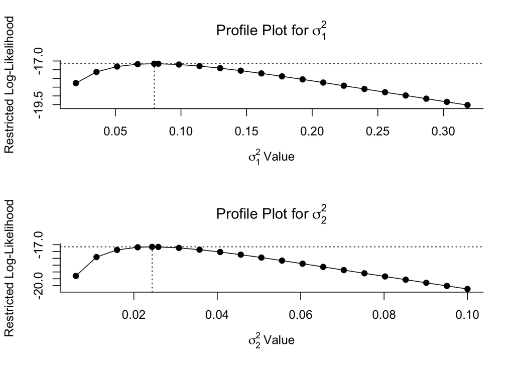

```r
par(mfrow=c(2,1))
profile(OPNMC_MLMA_3levels, sigma2=1)
profile(OPNMC_MLMA_3levels, sigma2=2)
```

Because the peaks of the plot correspond to the estimates of the given value(s) given by the model, we can be confident that both levels of random effect (within-study and between-study heterogeneity components) are identifiable.

## B. Primary meta-analysis

Note: The “coef_test” function from clubSandwich calculates robust standard errors and robust t-tests for the beta coefficient or the meta-analysis model, also called the pooled effect estimate.

### 1. Overall pooled Hedges’ G

```r
# Calculate variance-covariance matrix
OPNMC_Vmatrix_0.8 <- impute_covariance_matrix(vi = OPNMC_Data_HedgesG$G_Vi,
                                             cluster = OPNMC_Data_HedgesG$StudyPop_ID,
                                             r = 0.8)
# Run MA
OPNMC_MLMA <- rma.mv(yi = Gi,
                         V = OPNMC_Vmatrix_0.8,
                         data = OPNMC_Data_HedgesG,
                         random = ~ 1 | StudyPop_ID/ES_ID,
                         digits = 2)

# Calculate robust SEs/CIs
OPNMC_MLMA_robust_SE <- coef_test(OPNMC_MLMA, vcov = "CR2", digits = 2)
OPNMC_MLMA_robust_CI <- conf_int(OPNMC_MLMA, vcov = "CR2", digits = 2)
OPNMC_MLMA_robust <- full_join(OPNMC_MLMA_robust_SE,
                              OPNMC_MLMA_robust_CI)
# Calculate I^2 parameters
I2estimates_OPNMC <- var.comp(x = OPNMC_MLMA)

# Calculate CIs for Tao^2 estimates
OPNMC_MLMA_Tao2CI <- confint(OPNMC_MLMA)

# Calculate prediction interval
OPNMC_MLMA_PI <- predict(OPNMC_MLMA)

# Print weights
OPNMC_MLMA_Weights <- weights(OPNMC_MLMA)
```

### 2. Publication bias

```r
# Run MA model testing the impact of study precision (defined as the inverse of the total sample size) on effect size
(OPNMC_MLMA_PubBias_EggerTest_N <- rma.mv(yi = Gi,
                                         V = OPNMC_Vmatrix_0.8,
                                         data = OPNMC_Data_HedgesG,
                                         random = ~ 1 | StudyPop_ID/ES_ID,
                                         mod = (1/(sqrt(N_Total))),
                                         digits = 2))
```

```
##
## Multivariate Meta-Analysis Model (k = 42; method: REML)
##
## Variance Components:
##
##            estim  sqrt  nlvls  fixed             factor
## sigma^2.1   0.06  0.25     21     no        StudyPop_ID
## sigma^2.2   0.02  0.14     42     no  StudyPop_ID/ES_ID
##
## Test for Residual Heterogeneity:
## QE(df = 40) = 137.12, p-val < .01
##
## Test of Moderators (coefficient 2):
## QM(df = 1) = 6.69, p-val < .01
##
## Model Results:
##
##          estimate    se   zval  pval  ci.lb  ci.ub
## intrcpt      0.04  0.15   0.28  0.78  -0.26   0.34
## mods        -2.78  1.07  -2.59  <.01  -4.89  -0.67  **
##
## ---
## Signif. codes:  0 '***' 0.001 '**' 0.01 '*' 0.05 '.' 0.1 ' ' 1
```

```r
# Calculate robust SEs/CIs
OPNMC_MLMA_PubBias_EggerTest_N_robust <- coef_test(OPNMC_MLMA_PubBias_EggerTest_N, vcov = "CR2", digits = 2)
```

Based on the results of the cluster-robust Egger’s regression test for small study effects, study precision is an insignificant predictor of effect size. While there is no statistical sign of publication bias, the test had limited statistical power (df_Satt < 4).

## C. Secondary meta-analyses

### 1. Data sensitivity analyses

#### a) Outlier/influential effects

Note: Removed outlier and influential studies separately:

- Used Tukey’s Fences method to identify outlier effects
- Used Cook’s Distance to identify influential effects

```r
# Identify outlier effects via Tukey's fences method
Q1 <- quantile(OPNMC_Data_HedgesG$Gi)[2]
Q3 <- quantile(OPNMC_Data_HedgesG$Gi)[4]
IQR <- IQR(OPNMC_Data_HedgesG$Gi)
outlier.threshold.lower = Q1 - (IQR * 1.5)
outlier.threshold.upper = Q3 + (IQR * 1.5)
LowerOutliers <- OPNMC_Data_HedgesG$ES_ID[OPNMC_Data_HedgesG$Gi < outlier.threshold.lower] # ES_IDs 4, 5, 19
UpperOutliers <- OPNMC_Data_HedgesG$ES_ID[OPNMC_Data_HedgesG$Gi > outlier.threshold.upper] # None

# Run MA without outliers
OPNMC_MLMA_NoOutliers <- rma.mv(yi = Gi,
                               V = OPNMC_Vmatrix_0.8,
                               data = OPNMC_Data_HedgesG,
                               random = ~ 1 | StudyPop_ID/ES_ID,
                               digits = 2,
                               subset = (ES_ID != 4 & ES_ID != 5 & ES_ID != 19))

OPNMC_MLMA_NoOutliers_robustSE <- coef_test(OPNMC_MLMA_NoOutliers, vcov = "CR2")
OPNMC_MLMA_NoOutliers_robustCI <- conf_int(OPNMC_MLMA_NoOutliers, vcov = "CR2")
OPNMC_MLMA_NoOutliers_robust <- full_join(OPNMC_MLMA_NoOutliers_robustSE,
                                          OPNMC_MLMA_NoOutliers_robustCI)
```

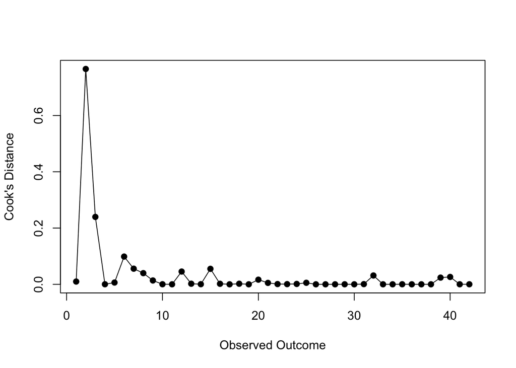

```r
# Identify influential effects via Cook's distance
CooksD_ES <- cooks.distance(OPNMC_MLMA)
plot(CooksD_ES, type="o", pch=19, xlab="Observed Outcome", ylab="Cook's Distance")
```

```r
InfluentialES <- CooksD_ES[(CooksD_ES > (3 * mean(CooksD_ES, na.rm = TRUE)))] # ES_IDs 2 and 3

# Run MA without influential effects
OPNMC_MLMA_NoInfluentials <- rma.mv(yi = Gi,
                               V = OPNMC_Vmatrix_0.8,
                               data = OPNMC_Data_HedgesG,
                               random = ~ 1 | StudyPop_ID/ES_ID,
                               digits = 2,
                               subset = (ES_ID != 2 & ES_ID != 3))

OPNMC_MLMA_NoInfluentials_robustSE <- coef_test(OPNMC_MLMA_NoInfluentials, vcov = "CR2")
OPNMC_MLMA_NoInfluentials_robustCI <- conf_int(OPNMC_MLMA_NoInfluentials, vcov = "CR2")
OPNMC_MLMA_NoInfluentials_robust <- full_join(OPNMC_MLMA_NoInfluentials_robustSE,
                                            OPNMC_MLMA_NoInfluentials_robustCI)
# Calculate I2 stats
I2estimates_NoOutliers <- var.comp(OPNMC_MLMA_NoOutliers)
I2estimates_NoInfluentials <- var.comp(OPNMC_MLMA_NoInfluentials)

# Summary table
OPNMC_MLMA_OutlierInfl_Results <- data.frame(
   Category = c("Primary", "No-Outlier-Effects", "No-Influential-Effects"),
   N_StudyPops = round(c(OPNMC_MLMA$s.nlevels[1], OPNMC_MLMA_NoOutliers$s.nlevels[1],
                         OPNMC_MLMA_NoInfluentials$s.nlevels[1]), digits = 2),
   N_Effects = round(c(OPNMC_MLMA$s.nlevels[2], OPNMC_MLMA_NoOutliers$s.nlevels[2],
                       OPNMC_MLMA_NoInfluentials$s.nlevels[2]), digits = 2),
   Estimate = round(c(OPNMC_MLMA$b, OPNMC_MLMA_NoOutliers$b,
                      OPNMC_MLMA_NoInfluentials$b), digits = 2),
   Robust_SE = round(c(OPNMC_MLMA_robust$SE, OPNMC_MLMA_NoOutliers_robust$SE,
                       OPNMC_MLMA_NoInfluentials_robust$SE), digits = 2),
   Robust_CIL = round(c(OPNMC_MLMA_robust$CI_L, OPNMC_MLMA_NoOutliers_robust$CI_L,
                        OPNMC_MLMA_NoInfluentials_robust$CI_L), digits = 2),
   Robust_CIU = round(c(OPNMC_MLMA_robust$CI_U, OPNMC_MLMA_NoOutliers_robust$CI_U,
                        OPNMC_MLMA_NoInfluentials_robust$CI_U), digits = 2),
   df_Satt = round(c(OPNMC_MLMA_robust$df, OPNMC_MLMA_NoOutliers_robust$df,
                     OPNMC_MLMA_NoInfluentials_robust$df), digits = 2),
   p_Satt = round(c(OPNMC_MLMA_robust$p_Satt, OPNMC_MLMA_NoOutliers_robust$p_Satt,
                    OPNMC_MLMA_NoInfluentials_robust$p_Satt), digits = 2),
   BtwStudyPop_T2 = round(c(OPNMC_MLMA$sigma2[1], OPNMC_MLMA_NoOutliers$sigma2[1],
                            OPNMC_MLMA_NoInfluentials$sigma2[1]), digits = 2),
   BtwStudyPop_I2 = round(c(I2estimates_OPNMC$results$`% of total variance`[3],
                            I2estimates_NoOutliers$results$`% of total variance`[3],
                            I2estimates_NoInfluentials$results$`% of total variance`[3]), digits = 2),
   WinStudyPop_T2 = round(c(OPNMC_MLMA$sigma2[2], OPNMC_MLMA_NoOutliers$sigma2[2],
                            OPNMC_MLMA_NoInfluentials$sigma2[2]), digits = 2),
   WinStudyPop_I2 = round(c(I2estimates_OPNMC$results$`% of total variance`[2],
                            I2estimates_NoOutliers$results$`% of total variance`[2],
                            I2estimates_NoInfluentials$results$`% of total variance`[2]), digits = 2),
   p_Heterog = round(c(OPNMC_MLMA$QEp, OPNMC_MLMA_NoOutliers$QEp,
                       OPNMC_MLMA_NoInfluentials$QEp), digits = 2))

OPNMC_MLMA_OutlierInfl_Results
```

```
##                 Category N_StudyPops N_Effects Estimate Robust_SE Robust_CIL
## 1                Primary          21        42    -0.30      0.09      -0.49
## 2     No-Outlier-Effects          18        39    -0.18      0.07      -0.33
## 3 No-Influential-Effects          20        40    -0.28      0.10      -0.49
##   Robust_CIU df_Satt p_Satt BtwStudyPop_T2 BtwStudyPop_I2 WinStudyPop_T2
## 1      -0.10   16.95   0.00           0.08          62.53           0.02
## 2      -0.02   11.74   0.03           0.02          35.04           0.02
## 3      -0.08   16.48   0.01           0.10          67.98           0.02
##   WinStudyPop_I2 p_Heterog
## 1          19.15         0
## 2          32.74         0
## 3          15.32         0
```

#### b) Correlation between dependent effect sizes

Note: Ran meta-analyses for the full range of R options to examine the impact of potential misspecification of the assumed correlation between dependent effect sizes used to construct a variance-covariance matrix.

```r
# r = 0
V_matrix_0 <- impute_covariance_matrix(vi = OPNMC_Data_HedgesG$G_Vi, cluster = OPNMC_Data_HedgesG$StudyPop_ID, r = 0)

OPNMC_MLMA_0 <- rma.mv(yi = Gi,
                      V = V_matrix_0,
                      data = OPNMC_Data_HedgesG,
                      random = ~ 1 | StudyPop_ID/ES_ID,
                      digits = 2)

OPNMC_MLMA_0_club_robustSE <- coef_test(OPNMC_MLMA_0, vcov = "CR2", digits = 2)
OPNMC_MLMA_0_club_robustCI <- conf_int(OPNMC_MLMA_0, vcov = "CR2", digits = 2)
OPNMC_MLMA_0_robust <- full_join(OPNMC_MLMA_0_club_robustSE, OPNMC_MLMA_0_club_robustCI)
# r = 0.2
V_matrix_0.2 <- impute_covariance_matrix(vi = OPNMC_Data_HedgesG$G_Vi,
                                      cluster = OPNMC_Data_HedgesG$StudyPop_ID,
                                      r = 0.2)
OPNMC_MLMA_0.2 <- rma.mv(yi = Gi,
                         V = V_matrix_0.2,
                         data = OPNMC_Data_HedgesG,
                         random = ~ 1 | StudyPop_ID/ES_ID)

OPNMC_MLMA_0.2_club_robustSE <- coef_test(OPNMC_MLMA_0.2, vcov = "CR2", digits = 2)
OPNMC_MLMA_0.2_club_robustCI <- conf_int(OPNMC_MLMA_0.2, vcov = "CR2", digits = 2)
OPNMC_MLMA_0.2_robust <- full_join(OPNMC_MLMA_0.2_club_robustSE, OPNMC_MLMA_0.2_club_robustCI)
# r = 0.4
V_matrix_0.4 <- impute_covariance_matrix(vi = OPNMC_Data_HedgesG$G_Vi,
                                      cluster = OPNMC_Data_HedgesG$StudyPop_ID,
                                      r = 0.4)
OPNMC_MLMA_0.4 <- rma.mv(yi = Gi,
                           V = V_matrix_0.4,
                           data = OPNMC_Data_HedgesG,
                           random = ~ 1 | StudyPop_ID/ES_ID)

OPNMC_MLMA_0.4_club_robustSE <- coef_test(OPNMC_MLMA_0.4, vcov = "CR2", digits = 2)
OPNMC_MLMA_0.4_club_robustCI <- conf_int(OPNMC_MLMA_0.4, vcov = "CR2", digits = 2)
OPNMC_MLMA_0.4_robust <- full_join(OPNMC_MLMA_0.4_club_robustSE, OPNMC_MLMA_0.4_club_robustCI)
# r = 0.6
V_matrix_0.6 <- impute_covariance_matrix(vi = OPNMC_Data_HedgesG$G_Vi,
                                      cluster = OPNMC_Data_HedgesG$StudyPop_ID,
                                      r = 0.6)
OPNMC_MLMA_0.6 <- rma.mv(yi = Gi,
                           V = V_matrix_0.6,
                           data = OPNMC_Data_HedgesG,
                           random = ~ 1 | StudyPop_ID/ES_ID)


OPNMC_MLMA_0.6_club_robustSE <- coef_test(OPNMC_MLMA_0.6, vcov = "CR2", digits = 2)
OPNMC_MLMA_0.6_club_robustCI <- conf_int(OPNMC_MLMA_0.6, vcov = "CR2", digits = 2)
OPNMC_MLMA_0.6_robust <- full_join(OPNMC_MLMA_0.6_club_robustSE, OPNMC_MLMA_0.6_club_robustCI)
# r = 0.8
V_matrix_0.8 <- impute_covariance_matrix(vi = OPNMC_Data_HedgesG$G_Vi,
                                        cluster = OPNMC_Data_HedgesG$StudyPop_ID,
                                        r = 0.8)

OPNMC_MLMA_0.8 <- rma.mv(yi = Gi,
                           V = V_matrix_0.8,
                           data = OPNMC_Data_HedgesG,
                           random = ~ 1 | StudyPop_ID/ES_ID,
                           digits = 3)

OPNMC_MLMA_0.8_club_robustSE <- coef_test(OPNMC_MLMA_0.8, vcov = "CR2", digits = 2)
OPNMC_MLMA_0.8_club_robustCI <- conf_int(OPNMC_MLMA_0.8, vcov = "CR2", digits = 2)
OPNMC_MLMA_0.8_robust <- full_join(OPNMC_MLMA_0.8_club_robustSE, OPNMC_MLMA_0.8_club_robustCI)
# r = 0.9
V_matrix_0.9 <- impute_covariance_matrix(vi = OPNMC_Data_HedgesG$G_Vi,
                                        cluster = OPNMC_Data_HedgesG$StudyPop_ID,
                                        r = 0.9)

OPNMC_MLMA_0.9 <- rma.mv(yi = Gi,
                           V = V_matrix_0.9,
                           data = OPNMC_Data_HedgesG,
                           random = ~ 1 | StudyPop_ID/ES_ID,
                           digits = 3)

OPNMC_MLMA_0.9_club_robustSE <- coef_test(OPNMC_MLMA_0.9, vcov = "CR2", digits = 2)
OPNMC_MLMA_0.9_club_robustCI <- conf_int(OPNMC_MLMA_0.9, vcov = "CR2", digits = 2)
OPNMC_MLMA_0.9_robust <- full_join(OPNMC_MLMA_0.9_club_robustSE, OPNMC_MLMA_0.9_club_robustCI)
# r = 0.95
V_matrix_0.95 <- impute_covariance_matrix(vi = OPNMC_Data_HedgesG$G_Vi,
                                      cluster = OPNMC_Data_HedgesG$StudyPop_ID,
                                      r = 0.95)

OPNMC_MLMA_0.95 <- rma.mv(yi = Gi,
                         V = V_matrix_0.95,
                         data = OPNMC_Data_HedgesG,
                         random = ~ 1 | StudyPop_ID/ES_ID,
                         digits = 3)

OPNMC_MLMA_0.95_club_robustSE <- coef_test(OPNMC_MLMA_0.95, vcov = "CR2", digits = 2)
OPNMC_MLMA_0.95_club_robustCI <- conf_int(OPNMC_MLMA_0.95, vcov = "CR2", digits = 2)
OPNMC_MLMA_0.95_robust <- full_join(OPNMC_MLMA_0.95_club_robustSE, OPNMC_MLMA_0.95_club_robustCI)
# Calculate I2 stats
I2estimates_0 <- var.comp(x = OPNMC_MLMA_0)
I2estimates_0.2 <- var.comp(x = OPNMC_MLMA_0.2)
I2estimates_0.4 <- var.comp(x = OPNMC_MLMA_0.4)
I2estimates_0.6 <- var.comp(x = OPNMC_MLMA_0.6)
I2estimates_0.8 <- var.comp(x = OPNMC_MLMA_0.8)
I2estimates_0.9 <- var.comp(x = OPNMC_MLMA_0.9)
I2estimates_0.95 <- var.comp(x = OPNMC_MLMA_0.95)

# Summary table
RhoChoiceSA_ResultsTable = data.frame(
    Rho_choice = c(0, 0.2, 0.4, 0.6, 0.8, 0.9, 0.95),
    N_StudyPops = round(c(OPNMC_MLMA_0$s.nlevels[1], OPNMC_MLMA_0.2$s.nlevels[1],OPNMC_MLMA_0.4$s.nlevels[1],
                        OPNMC_MLMA_0.6$s.nlevels[1], OPNMC_MLMA_0.8$s.nlevels[1],OPNMC_MLMA_0.9$s.nlevels[1],
                        OPNMC_MLMA_0.95$s.nlevels[1]), digits = 2),
    N_Effects = round(c(OPNMC_MLMA_0$s.nlevels[2], OPNMC_MLMA_0.2$s.nlevels[2],OPNMC_MLMA_0.4$s.nlevels[2],
                        OPNMC_MLMA_0.6$s.nlevels[2], OPNMC_MLMA_0.8$s.nlevels[2],OPNMC_MLMA_0.9$s.nlevels[2],
                        OPNMC_MLMA_0.95$s.nlevels[2]), digits = 2),
    Estimate = round(c(OPNMC_MLMA_0$b, OPNMC_MLMA_0.2$b,OPNMC_MLMA_0.4$b,
                        OPNMC_MLMA_0.6$b, OPNMC_MLMA_0.8$b,OPNMC_MLMA_0.9$b,
                        OPNMC_MLMA_0.95$b), digits = 2),
    Robsut_SE = round(c(OPNMC_MLMA_0_robust$SE, OPNMC_MLMA_0.2_robust$SE,OPNMC_MLMA_0.4_robust$SE,
                        OPNMC_MLMA_0.6_robust$SE, OPNMC_MLMA_0.8_robust$SE,OPNMC_MLMA_0.9_robust$SE,
                        OPNMC_MLMA_0.95_robust$SE), digits = 2),
    Robust_CIL = round(c(OPNMC_MLMA_0_robust$CI_L, OPNMC_MLMA_0.2_robust$CI_L, OPNMC_MLMA_0.4_robust$CI_L,
                        OPNMC_MLMA_0.6_robust$CI_L, OPNMC_MLMA_0.8_robust$CI_L, OPNMC_MLMA_0.9_robust$CI_L,
                        OPNMC_MLMA_0.95_robust$CI_L), digits = 2),
    Robust_CIU = round(c(OPNMC_MLMA_0_robust$CI_U, OPNMC_MLMA_0.2_robust$CI_U, OPNMC_MLMA_0.4_robust$CI_U,
                        OPNMC_MLMA_0.6_robust$CI_U, OPNMC_MLMA_0.8_robust$CI_U, OPNMC_MLMA_0.9_robust$CI_U,
                        OPNMC_MLMA_0.95_robust$CI_U), digits = 2),
    df_Satt = round(c(OPNMC_MLMA_0_robust$df, OPNMC_MLMA_0.2_robust$df, OPNMC_MLMA_0.4_robust$df,
                        OPNMC_MLMA_0.6_robust$df, OPNMC_MLMA_0.8_robust$df, OPNMC_MLMA_0.9_robust$df,
                        OPNMC_MLMA_0.95_robust$df), digits = 2),
    p_Satt = round(c(OPNMC_MLMA_0_robust$p_Satt, OPNMC_MLMA_0.2_robust$p_Satt, OPNMC_MLMA_0.4_robust$p_Satt,
                        OPNMC_MLMA_0.6_robust$p_Satt, OPNMC_MLMA_0.8_robust$p_Satt, OPNMC_MLMA_0.9_robust$p_Satt,
                        OPNMC_MLMA_0.95_robust$p_Satt), digits = 2),
    BtwStudyPop_T2 = round(c(OPNMC_MLMA_0$sigma2[1], OPNMC_MLMA_0.2$sigma2[1], OPNMC_MLMA_0.4$sigma2[1],
                            OPNMC_MLMA_0.6$sigma2[1], OPNMC_MLMA_0.8$sigma2[1], OPNMC_MLMA_0.9$sigma2[1],
                            OPNMC_MLMA_0.95$sigma2[1]), digits = 2),
    BtwStudyPop_I2 = round(c(I2estimates_0$results$`% of total variance`[3], I2estimates_0.2$results$`% of total variance`[3],
                          I2estimates_0.4$results$`% of total variance`[3], I2estimates_0.6$results$`% of total variance`[3],
                          I2estimates_0.8$results$`% of total variance`[3], I2estimates_0.9$results$`% of total variance`[3],
                          I2estimates_0.95$results$`% of total variance`[3]),
                        digits = 2),
    WinStudyPop_T2 = round(c(OPNMC_MLMA_0$sigma2[2], OPNMC_MLMA_0.2$sigma2[2], OPNMC_MLMA_0.4$sigma2[2],
                            OPNMC_MLMA_0.6$sigma2[2], OPNMC_MLMA_0.8$sigma2[2], OPNMC_MLMA_0.9$sigma2[2],
                            OPNMC_MLMA_0.95$sigma2[2]), digits = 2),
    WinStudyPop_I2 = round(c(I2estimates_0$results$`% of total variance`[2], I2estimates_0.2$results$`% of total variance`[2],
                          I2estimates_0.4$results$`% of total variance`[2], I2estimates_0.6$results$`% of total variance`[2],
                          I2estimates_0.8$results$`% of total variance`[2], I2estimates_0.9$results$`% of total variance`[2],
                          I2estimates_0.95$results$`% of total variance`[2]), digits = 2),
    p_Heterog = round(c(OPNMC_MLMA_0$QEp, OPNMC_MLMA_0.2$QEp,OPNMC_MLMA_0.4$QEp,
                        OPNMC_MLMA_0.6$QEp, OPNMC_MLMA_0.8$QEp,OPNMC_MLMA_0.9$QEp,
                        OPNMC_MLMA_0.95$QEp), digits = 2))

RhoChoiceSA_ResultsTable
```

```
##   Rho_choice N_StudyPops N_Effects Estimate Robsut_SE Robust_CIL Robust_CIU
## 1       0.00          21        42    -0.31      0.09      -0.49      -0.12
## 2       0.20          21        42    -0.31      0.09      -0.49      -0.12
## 3       0.40          21        42    -0.30      0.09      -0.49      -0.12
## 4       0.60          21        42    -0.30      0.09      -0.49      -0.11
## 5       0.80          21        42    -0.30      0.09      -0.49      -0.10
## 6       0.90          21        42    -0.29      0.09      -0.48      -0.10
## 7       0.95          21        42    -0.29      0.09      -0.48      -0.09
##   df_Satt p_Satt BtwStudyPop_T2 BtwStudyPop_I2 WinStudyPop_T2 WinStudyPop_I2
## 1   17.10   0.00           0.09          77.91           0.00           2.11
## 2   17.20   0.00           0.09          77.17           0.00           3.03
## 3   17.24   0.00           0.09          76.06           0.01           4.30
## 4   17.22   0.00           0.09          73.98           0.01           6.62
## 5   16.95   0.00           0.08          62.53           0.02          19.15
## 6   16.51   0.01           0.07          49.80           0.05          33.07
## 7   16.24   0.01           0.06          43.85           0.06          39.63
##   p_Heterog
## 1         0
## 2         0
## 3         0
## 4         0
## 5         0
## 6         0
## 7         0
```

#### c) Heterogeneity estimate (confidence interval)

Note: Ran meta-analyses using the lower and upper bounds of the REML heterogeneity point estimates for each level of random effect.

```r
# Calculate CI around Tao2 estimates of primary meta-analysis
OPNMC_MLMA_Tao2CI <- confint(OPNMC_MLMA)

# Fix sigma values at lower bound of CI
OPNMC_MLMA_Tao2CILB <- rma.mv(yi = Gi,
                              V = OPNMC_Vmatrix_0.8,
                              data = OPNMC_Data_HedgesG,
                              random = ~ 1 | StudyPop_ID/ES_ID,
                              sigma2 = c(0.01, 0.01),
                              digits = 2)

OPNMC_MLMA_Tao2CILB_robustSE <- coef_test(OPNMC_MLMA_Tao2CILB, vcov = "CR2", digits = 2)
OPNMC_MLMA_Tao2CILB_robustCI <- conf_int(OPNMC_MLMA_Tao2CILB, vcov = "CR2", digits = 2)
OPNMC_MLMA_Tao2CILB_robust <- full_join(OPNMC_MLMA_Tao2CILB_robustSE,  OPNMC_MLMA_Tao2CILB_robustCI)
# Fix sigma values at upper bound of CI
OPNMC_MLMA_Tao2CIUB <- rma.mv(yi = Gi,
                                    V = V_matrix_0.8,
                                    data = OPNMC_Data_HedgesG,
                                    random = ~ 1 | StudyPop_ID/ES_ID,
                                    sigma2 = c(0.28, 0.07),
                                    digits = 2)

OPNMC_MLMA_Tao2CIUB_robustSE <- coef_test(OPNMC_MLMA_Tao2CIUB, vcov = "CR2", digits = 2)
OPNMC_MLMA_Tao2CIUB_robustCI <- conf_int(OPNMC_MLMA_Tao2CIUB, vcov = "CR2", digits = 2)
OPNMC_MLMA_Tao2CIUB_robust <- full_join(OPNMC_MLMA_Tao2CIUB_robustSE, OPNMC_MLMA_Tao2CIUB_robustCI)
# Calculate I^2 parameters
I2estimates_0.8_Tao2CILB <- var.comp(OPNMC_MLMA_Tao2CILB)
I2estimates_0.8_Tao2CIUB <- var.comp(OPNMC_MLMA_Tao2CIUB)

# Summary table
OPNMC_MLMA_Tao2CISA_Summary <- data.frame(
   Tao2_EstimateType = c("Point Estimate", " Lower Bound", "Upper Bound"),
   N_StudyPops = round(c(OPNMC_MLMA$s.nlevels[1], OPNMC_MLMA_Tao2CILB$s.nlevels[1],
                         OPNMC_MLMA_Tao2CIUB$s.nlevels[1]), digits = 2),
   N_Effects = round(c(OPNMC_MLMA$s.nlevels[2], OPNMC_MLMA_Tao2CILB$s.nlevels[2],
                          OPNMC_MLMA_Tao2CIUB$s.nlevels[2]), digits = 2),
   Estimate = round(c(OPNMC_MLMA$b, OPNMC_MLMA_Tao2CILB$b,
                          OPNMC_MLMA_Tao2CIUB$b), digits = 2),
   Robust_SE = round(c(OPNMC_MLMA_robust$SE, OPNMC_MLMA_Tao2CILB_robust$SE,
                          OPNMC_MLMA_Tao2CIUB_robust$SE), digits = 2),
   Robust_CIL = round(c(OPNMC_MLMA_robust$CI_L, OPNMC_MLMA_Tao2CILB_robust$CI_L,
                          OPNMC_MLMA_Tao2CIUB_robust$CI_L), digits = 2),
   Robust_CIU = round(c(OPNMC_MLMA_robust$CI_U, OPNMC_MLMA_Tao2CILB_robust$CI_U,
                          OPNMC_MLMA_Tao2CIUB_robust$CI_U), digits = 2),
   df_Satt = round(c(OPNMC_MLMA_robust$df, OPNMC_MLMA_Tao2CILB_robust$df,
                          OPNMC_MLMA_Tao2CIUB_robust$df), digits = 2),
   p_Satt = round(c(OPNMC_MLMA_robust$p_Satt, OPNMC_MLMA_Tao2CILB_robust$p_Satt,
                          OPNMC_MLMA_Tao2CIUB_robust$p_Satt), digits = 2),
   BtwStudyPop_T2 = round(c(OPNMC_MLMA$sigma2[1], OPNMC_MLMA_Tao2CILB$sigma2[1],
                            OPNMC_MLMA_Tao2CIUB$sigma2[1]), digits = 2),
   BtwStudyPop_I2 <- round(c(I2estimates_0.8$results$`% of total variance`[3],
                           I2estimates_0.8_Tao2CILB$results$`% of total variance`[3],
                           I2estimates_0.8_Tao2CIUB$results$`% of total variance`[3]), digits = 2),
   WinStudyPop_T2 = round(c(OPNMC_MLMA$sigma2[2], OPNMC_MLMA_Tao2CILB$sigma2[2],
                            OPNMC_MLMA_Tao2CIUB$sigma2[2]), digits = 2),
   WinStudyPop_I2 <- round(c(I2estimates_0.8$results$`% of total variance`[2],
                           I2estimates_0.8_Tao2CILB$results$`% of total variance`[2],
                           I2estimates_0.8_Tao2CIUB$results$`% of total variance`[2]), digits = 2),
   p_Heterog = round(c(OPNMC_MLMA$QEp, OPNMC_MLMA_Tao2CILB$QEp,
                          OPNMC_MLMA_Tao2CIUB$QEp), digits = 2))

OPNMC_MLMA_Tao2CISA_Summary
```

```
##   Tao2_EstimateType N_StudyPops N_Effects Estimate Robust_SE Robust_CIL
## 1    Point Estimate          21        42    -0.30      0.09      -0.49
## 2       Lower Bound          21        42    -0.20      0.10      -0.42
## 3       Upper Bound          21        42    -0.34      0.10      -0.55
##   Robust_CIU df_Satt p_Satt BtwStudyPop_T2
## 1      -0.10   16.95   0.00           0.08
## 2       0.02    8.97   0.07           0.01
## 3      -0.13   18.93   0.00           0.28
##   BtwStudyPop_I2....round.c.I2estimates_0.8.results....of.total.variance..3...
## 1                                                                        62.53
## 2                                                                        23.08
## 3                                                                        75.00
##   WinStudyPop_T2
## 1           0.02
## 2           0.01
## 3           0.07
##   WinStudyPop_I2....round.c.I2estimates_0.8.results....of.total.variance..2...
## 1                                                                        19.15
## 2                                                                        23.08
## 3                                                                        18.75
##   p_Heterog
## 1         0
## 2         0
## 3         0
```

#### d) Data manipulations (imputations, log to raw scale, and effect size transformations)

Three types of data manipulation sensitivity analyses were performed:

- SA_Imputation: Removed effect sizes calculated with one or more data imputation
  - Melgarejo et al., 2015
  - Perry et al., 2007
  - Tan et al., 2005
- SA_Log: Removed effect sizes that were back transformed from log to raw scale
  - Melgarejo et al., 2015
  - Perry et al., 2007
  - Swan et al., 2003
  - Tan et al., 2005
- SA_Transform: Removed effect sizes that were transformed to standardized mean difference index
  - Manikandan et al., 2021
  - Meeker et al., 2004
  - Melgarejo et al., 2015
  - Perez-Herrera et al., 2008
  - Perry et al., 2011
  - Swan et al., 2003
  - Whorton et al., 1979

See the ‘Data Manipulations (SA1 & SA2)’ tab of the extracted study results data for more detail.

```r
# SA_Imputation
OPNMC_MLMA_SA1 <- rma.mv(yi = Gi,
                           V = V_matrix_0.8,
                           data = OPNMC_Data_HedgesG,
                           random = ~ 1 | StudyPop_ID/ES_ID,
                           subset = (OPNMC_Data_HedgesG$SA_Imputation == 0))

OPNMC_MLMA_SA1_robustSE <- coef_test(OPNMC_MLMA_SA1, vcov = "CR2", digits = 2)
OPNMC_MLMA_SA1_robustCI <- conf_int(OPNMC_MLMA_SA1, vcov = "CR2", digits = 2)
OPNMC_MLMA_SA1_robust <- full_join(OPNMC_MLMA_SA1_robustSE, OPNMC_MLMA_SA1_robustCI)
# SA_Log
OPNMC_MLMA_SA2 <- rma.mv(yi = Gi,
                           V = V_matrix_0.8,
                           data = OPNMC_Data_HedgesG,
                           random = ~ 1 | StudyPop_ID/ES_ID,
                           subset = (OPNMC_Data_HedgesG$SA_Log == 0))

OPNMC_MLMA_SA2_robustSE <- coef_test(OPNMC_MLMA_SA2, vcov = "CR2", digits = 2)
OPNMC_MLMA_SA2_robustCI <- conf_int(OPNMC_MLMA_SA2, vcov = "CR2", digits = 2)
OPNMC_MLMA_SA2_robust <- full_join(OPNMC_MLMA_SA2_robustSE, OPNMC_MLMA_SA2_robustCI)
# SA_Transform
OPNMC_MLMA_SA3 <- rma.mv(yi = Gi,
                           V = V_matrix_0.8,
                           data = OPNMC_Data_HedgesG,
                           random = ~ 1 | StudyPop_ID/ES_ID,
                           subset = (OPNMC_Data_HedgesG$SA_Transform == 0))

OPNMC_MLMA_SA3_robustSE <- coef_test(OPNMC_MLMA_SA3, vcov = "CR2", digits = 2)
OPNMC_MLMA_SA3_robustCI <- conf_int(OPNMC_MLMA_SA3, vcov = "CR2", digits = 2)
OPNMC_MLMA_SA3_robust <- full_join(OPNMC_MLMA_SA3_robustSE, OPNMC_MLMA_SA3_robustCI)
# Calculate I^2 parameters
I2estimates_SA1 <- var.comp(x = OPNMC_MLMA_SA1)
I2estimates_SA2 <- var.comp(x = OPNMC_MLMA_SA2)
I2estimates_SA3 <- var.comp(x = OPNMC_MLMA_SA3)

# Summary table
OPNMC_MLMA_DataManipSA_ResultsTable <- data.frame(
   SA_Status = c("SA1","SA2", "SA3"),
   N_StudyPops = round(c(OPNMC_MLMA_SA1$s.nlevels[1], OPNMC_MLMA_SA2$s.nlevels[1],
                         OPNMC_MLMA_SA3$s.nlevels[1]), digits = 2),
   N_Effects = round(c(OPNMC_MLMA_SA1$s.nlevels[2], OPNMC_MLMA_SA2$s.nlevels[2],
                       OPNMC_MLMA_SA3$s.nlevels[2]), digits = 2),
   Estimate = round(c(OPNMC_MLMA_SA1$b, OPNMC_MLMA_SA2$b,
                          OPNMC_MLMA_SA3$b), digits = 2),
   Robust_SE = round(c(OPNMC_MLMA_SA1_robust$SE, OPNMC_MLMA_SA2_robust$SE,
                          OPNMC_MLMA_SA3_robust$SE), digits = 2),
   Robust_CIL = round(c(OPNMC_MLMA_SA1_robust$CI_L, OPNMC_MLMA_SA2_robust$CI_L,
                          OPNMC_MLMA_SA3_robust$CI_L), digits = 2),
   Robust_CIU = round(c(OPNMC_MLMA_SA1_robust$CI_U, OPNMC_MLMA_SA2_robust$CI_U,
                          OPNMC_MLMA_SA3_robust$CI_U), digits = 2),
   df_Satt = round(c(OPNMC_MLMA_SA1_robust$df, OPNMC_MLMA_SA2_robust$df,
                          OPNMC_MLMA_SA3_robust$df), digits = 2),
   p_Satt = round(c(OPNMC_MLMA_SA1_robust$p_Satt, OPNMC_MLMA_SA2_robust$p_Satt,
                          OPNMC_MLMA_SA3_robust$p_Satt), digits = 2),
   BtwStudyPop_T2 = round(c(OPNMC_MLMA_SA1$sigma2[1], OPNMC_MLMA_SA2$sigma2[1],
                            OPNMC_MLMA_SA3$sigma2[1]), digits = 2),
   BtwStudyPop_I2 = round(c(I2estimates_SA1$results$`% of total variance`[3],
                          I2estimates_SA2$results$`% of total variance`[3],
                          I2estimates_SA3$results$`% of total variance`[3]), digits = 2),
   WinStudyPop_T2 = round(c(OPNMC_MLMA_SA1$sigma2[2], OPNMC_MLMA_SA2$sigma2[2],
                            OPNMC_MLMA_SA3$sigma2[2]), digits = 2),
   WinStudyPop_I2 = round(c(I2estimates_SA1$results$`% of total variance`[2],
                          I2estimates_SA2$results$`% of total variance`[2],
                          I2estimates_SA3$results$`% of total variance`[2]), digits = 2),
   p_Heterog = round(c(OPNMC_MLMA_SA1$QEp, OPNMC_MLMA_SA2$QEp,
                          OPNMC_MLMA_SA3$QEp), digits = 2))

OPNMC_MLMA_DataManipSA_ResultsTable
```

```
##   SA_Status N_StudyPops N_Effects Estimate Robust_SE Robust_CIL Robust_CIU
## 1       SA1          17        32    -0.38      0.11      -0.62      -0.13
## 2       SA2          17        29    -0.39      0.11      -0.62      -0.15
## 3       SA3          15        20    -0.39      0.12      -0.65      -0.13
##   df_Satt p_Satt BtwStudyPop_T2 BtwStudyPop_I2 WinStudyPop_T2 WinStudyPop_I2
## 1   13.61   0.01           0.10          56.91           0.05          31.11
## 2   13.76   0.00           0.10          74.69           0.02          11.94
## 3   12.53   0.01           0.09          47.09           0.04          21.36
##   p_Heterog
## 1         0
## 2         0
## 3         0
```

### 2. Moderator sensitivity analyses

#### a) Risk of Bias

Note: Removed studies with high or probably high risk of bias in each domain of bias.

```r
# Blinding bias
OPNMC_MLMA_BlindLow <- rma.mv(yi = Gi,
                             V = OPNMC_Vmatrix_0.8,
                             data = OPNMC_Data_HedgesG,
                             random = ~ 1 | StudyPop_ID/ES_ID,
                             subset = (B_Bias == "Low" |
                               B_Bias == "P_Low"))

OPNMC_MLMA_BlindLow_robustSE <- coef_test(OPNMC_MLMA_BlindLow, vcov = "CR2")
OPNMC_MLMA_BlindLow_robustCI <- conf_int(OPNMC_MLMA_BlindLow, vcov = "CR2")
OPNMC_MLMA_BlindLow_robust <- full_join(OPNMC_MLMA_BlindLow_robustSE,
                                       OPNMC_MLMA_BlindLow_robustCI)
# Recruitment bias
OPNMC_MLMA_RecruitLow <- rma.mv(yi = Gi,
                               V = OPNMC_Vmatrix_0.8,
                               data = OPNMC_Data_HedgesG,
                               random = ~ 1 | StudyPop_ID/ES_ID,
                               subset = (R_Bias == "Low" |
                                         R_Bias == "P_Low"))

OPNMC_MLMA_RecruitLow_robustSE <- coef_test(OPNMC_MLMA_RecruitLow, vcov = "CR2")
OPNMC_MLMA_RecruitLow_robustCI <- conf_int(OPNMC_MLMA_RecruitLow, vcov = "CR2")
OPNMC_MLMA_RecruitLow_robust <- full_join(OPNMC_MLMA_RecruitLow_robustSE,
                                         OPNMC_MLMA_RecruitLow_robustCI)
# Exposure assessment bias
OPNMC_MLMA_ExpLow <- rma.mv(yi = Gi,
                           V = OPNMC_Vmatrix_0.8,
                           data = OPNMC_Data_HedgesG,
                           random = ~ 1 | StudyPop_ID/ES_ID,
                           subset = (E_Bias == "P_Low" |
                                       E_Bias == "Low"))

OPNMC_MLMA_ExpLow_robustSE <- coef_test(OPNMC_MLMA_ExpLow, vcov = "CR2")
OPNMC_MLMA_ExpLow_robustCI <- conf_int(OPNMC_MLMA_ExpLow, vcov = "CR2")
OPNMC_MLMA_ExpLow_robust <- full_join(OPNMC_MLMA_ExpLow_robustSE,
                                     OPNMC_MLMA_ExpLow_robustCI)
# Confounding bias
OPNMC_MLMA_ConfLow <- rma.mv(yi = Gi,
                            V = OPNMC_Vmatrix_0.8,
                            data = OPNMC_Data_HedgesG,
                            random = ~ 1 | StudyPop_ID/ES_ID,
                            subset = (C_Bias == "Low"))

OPNMC_MLMA_ConfLow_robustSE <- coef_test(OPNMC_MLMA_ConfLow, vcov = "CR2")
OPNMC_MLMA_ConfLow_robustCI <- conf_int(OPNMC_MLMA_ConfLow, vcov = "CR2")
OPNMC_MLMA_ConfLow_robust <- full_join(OPNMC_MLMA_ConfLow_robustSE,
                                      OPNMC_MLMA_ConfLow_robustCI)
# Outcome bias
OPNMC_MLMA_OutLow <- rma.mv(yi = Gi,
                               V = OPNMC_Vmatrix_0.8,
                               data = OPNMC_Data_HedgesG,
                               random = ~ 1 | StudyPop_ID/ES_ID,
                               subset = (O_Bias == "Low" |
                                         O_Bias == "P_Low"))

OPNMC_MLMA_OutLow_robustSE <- coef_test(OPNMC_MLMA_OutLow, vcov = "CR2")
OPNMC_MLMA_OutLow_robustCI <- conf_int(OPNMC_MLMA_OutLow, vcov = "CR2")
OPNMC_MLMA_OutLow_robust <- full_join(OPNMC_MLMA_OutLow_robustSE,
                                    OPNMC_MLMA_OutLow_robustCI)
# SOR bias
OPNMC_MLMA_SORLow <- rma.mv(yi = Gi,
                               V = OPNMC_Vmatrix_0.8,
                               data = OPNMC_Data_HedgesG,
                               random = ~ 1 | StudyPop_ID/ES_ID,
                               subset = (SOR_Bias == "Low" |
                                         SOR_Bias == "P_Low"))

OPNMC_MLMA_SORLow_robustSE <- coef_test(OPNMC_MLMA_SORLow, vcov = "CR2")
OPNMC_MLMA_SORLow_robustCI <- conf_int(OPNMC_MLMA_SORLow, vcov = "CR2")
OPNMC_MLMA_SORLow_robust <- full_join(OPNMC_MLMA_SORLow_robustSE,
                                    OPNMC_MLMA_SORLow_robustCI)
# COI bias
OPNMC_MLMA_COILow <- rma.mv(yi = Gi,
                             V = OPNMC_Vmatrix_0.8,
                             data = OPNMC_Data_HedgesG,
                             random = ~ 1 | StudyPop_ID/ES_ID,
                             subset = (COI_Bias == "Low" |
                                       COI_Bias == "P_Low"))

OPNMC_MLMA_COILow_robustSE <- coef_test(OPNMC_MLMA_COILow, vcov = "CR2")
OPNMC_MLMA_COILow_robustCI <- conf_int(OPNMC_MLMA_COILow, vcov = "CR2")
OPNMC_MLMA_COILow_robust <- full_join(OPNMC_MLMA_COILow_robustSE,
                                     OPNMC_MLMA_COILow_robustCI)
# Calculate I2 stats
I2estimates_BlindLow <- var.comp(OPNMC_MLMA_BlindLow)
I2estimates_RecruitLow <- var.comp(OPNMC_MLMA_RecruitLow)
I2estimates_ExpLow <- var.comp(OPNMC_MLMA_ExpLow)
I2estimates_ConfLow <- var.comp(OPNMC_MLMA_ConfLow)
I2estimates_OutLow <- var.comp(OPNMC_MLMA_OutLow)
I2estimates_SORLow <- var.comp(OPNMC_MLMA_SORLow)
I2estimates_COILow <- var.comp(OPNMC_MLMA_COILow)

# Summary table
OPNMCData_RiskofBias_ResultsTable <- data.frame(
  Category = c("Total", "Blind-Low", "Recruit-Low", "Exp-Low", "Conf-Low", "Outcome-Low","SOR-Low", "COI-Low"),
  No_StudyPops = (round(c(OPNMC_MLMA$s.nlevels[1], OPNMC_MLMA_BlindLow$s.nlevels[1],
                        OPNMC_MLMA_RecruitLow$s.nlevels[1], OPNMC_MLMA_ExpLow$s.nlevels[1],
                        OPNMC_MLMA_ConfLow$s.nlevels[1],
                        OPNMC_MLMA_OutLow$s.nlevels[1],
                        OPNMC_MLMA_SORLow$s.nlevels[1],
                        OPNMC_MLMA_COILow$s.nlevels[1]), digits = 2)),
  No_Effects = (round(c(OPNMC_MLMA$s.nlevels[2], OPNMC_MLMA_BlindLow$s.nlevels[2],
                        OPNMC_MLMA_RecruitLow$s.nlevels[2], OPNMC_MLMA_ExpLow$s.nlevels[2],
                        OPNMC_MLMA_ConfLow$s.nlevels[2],
                        OPNMC_MLMA_OutLow$s.nlevels[2],
                        OPNMC_MLMA_SORLow$s.nlevels[2],
                        OPNMC_MLMA_COILow$s.nlevels[2]), digits = 2)),
  Estimate = (round(c(OPNMC_MLMA$b, OPNMC_MLMA_BlindLow$b,
                      OPNMC_MLMA_RecruitLow$b, OPNMC_MLMA_ExpLow$b,
                      OPNMC_MLMA_ConfLow$b,
                      OPNMC_MLMA_OutLow$b,
                      OPNMC_MLMA_SORLow$b,
                      OPNMC_MLMA_COILow$b), digits = 2)),
  Robust_SE = (round(c(OPNMC_MLMA_robust$SE, OPNMC_MLMA_BlindLow_robust$SE,
                      OPNMC_MLMA_RecruitLow_robust$SE, OPNMC_MLMA_ExpLow_robust$SE,
                      OPNMC_MLMA_ConfLow_robust$SE,
                      OPNMC_MLMA_OutLow_robust$SE,
                      OPNMC_MLMA_SORLow_robust$SE,
                      OPNMC_MLMA_COILow_robust$SE), digits = 2)),
  Robust_CIL = (round(c(OPNMC_MLMA_robust$CI_L, OPNMC_MLMA_BlindLow_robust$CI_L,
                         OPNMC_MLMA_RecruitLow_robust$CI_L, OPNMC_MLMA_ExpLow_robust$CI_L,
                         OPNMC_MLMA_ConfLow_robust$CI_L,
                         OPNMC_MLMA_OutLow_robust$CI_L,
                         OPNMC_MLMA_SORLow_robust$CI_L,
                         OPNMC_MLMA_COILow_robust$CI_L), digits = 2)),
  Robust_CIU = (round(c(OPNMC_MLMA_robust$CI_U, OPNMC_MLMA_BlindLow_robust$CI_U,
                         OPNMC_MLMA_RecruitLow_robust$CI_U, OPNMC_MLMA_ExpLow_robust$CI_U,
                         OPNMC_MLMA_ConfLow_robust$CI_U,
                         OPNMC_MLMA_OutLow_robust$CI_U,
                         OPNMC_MLMA_SORLow_robust$CI_U,
                         OPNMC_MLMA_COILow_robust$CI_U), digits = 2)),
  df_Satt = (round(c(OPNMC_MLMA_robust$df, OPNMC_MLMA_BlindLow_robust$df,
                       OPNMC_MLMA_RecruitLow_robust$df, OPNMC_MLMA_ExpLow_robust$df,
                       OPNMC_MLMA_ConfLow_robust$df,
                       OPNMC_MLMA_OutLow_robust$df,
                       OPNMC_MLMA_SORLow_robust$df,
                       OPNMC_MLMA_COILow_robust$df), digits = 2)),
  p_Satt = (round(c(OPNMC_MLMA_robust$p_Satt, OPNMC_MLMA_BlindLow_robust$p_Satt,
                    OPNMC_MLMA_RecruitLow_robust$p_Satt, OPNMC_MLMA_ExpLow_robust$p_Satt,
                    OPNMC_MLMA_ConfLow_robust$p_Satt,
                    OPNMC_MLMA_OutLow_robust$p_Satt,
                    OPNMC_MLMA_SORLow_robust$p_Satt,
                    OPNMC_MLMA_COILow_robust$p_Satt), digits = 2)),
  BtwStudyPop_T2 = (round(c(OPNMC_MLMA$sigma2[1], OPNMC_MLMA_BlindLow$sigma2[1],
                        OPNMC_MLMA_RecruitLow$sigma2[1], OPNMC_MLMA_ExpLow$sigma2[1],
                        OPNMC_MLMA_ConfLow$sigma2[1],
                        OPNMC_MLMA_OutLow$sigma2[1],
                        OPNMC_MLMA_SORLow$sigma2[1],
                        OPNMC_MLMA_COILow$sigma2[1]), digits = 2)),
  BtwStudyPop_I2 = (round(c(I2estimates_OPNMC$results$`% of total variance`[3],
                        I2estimates_BlindLow$results$`% of total variance`[3],
                        I2estimates_RecruitLow$results$`% of total variance`[3],
                        I2estimates_ExpLow$results$`% of total variance`[3],
                        I2estimates_ConfLow$results$`% of total variance`[3],
                        I2estimates_OutLow$results$`% of total variance`[3],
                        I2estimates_SORLow$results$`% of total variance`[3],
                        I2estimates_COILow$results$`% of total variance`[3]),
                      digits = 2)),
  WinStudyPop_T2 = (round(c(OPNMC_MLMA$sigma2[2], OPNMC_MLMA_BlindLow$sigma2[2],
                        OPNMC_MLMA_RecruitLow$sigma2[2], OPNMC_MLMA_ExpLow$sigma2[1],
                        OPNMC_MLMA_ConfLow$sigma2[2],
                        OPNMC_MLMA_OutLow$sigma2[2],
                        OPNMC_MLMA_SORLow$sigma2[2],
                        OPNMC_MLMA_COILow$sigma2[2]), digits = 2)),
  WinStudyPop_I2 = (round(c(I2estimates_OPNMC$results$`% of total variance`[2],
                        I2estimates_BlindLow$results$`% of total variance`[2],
                        I2estimates_RecruitLow$results$`% of total variance`[2],
                        I2estimates_ExpLow$results$`% of total variance`[2],
                        I2estimates_ConfLow$results$`% of total variance`[2],
                        I2estimates_OutLow$results$`% of total variance`[2],
                        I2estimates_SORLow$results$`% of total variance`[2],
                        I2estimates_COILow$results$`% of total variance`[2]),
                      digits = 2)),
  P_Heterog = (round(c(OPNMC_MLMA$QEp, OPNMC_MLMA_BlindLow$QEp,
                       OPNMC_MLMA_RecruitLow$QEp, OPNMC_MLMA_ExpLow$QEp,
                       OPNMC_MLMA_ConfLow$QEp,
                       OPNMC_MLMA_OutLow$QEp,
                       OPNMC_MLMA_SORLow$QEp,
                       OPNMC_MLMA_COILow$QEp), digits = 2)))

OPNMCData_RiskofBias_ResultsTable
```

```
##      Category No_StudyPops No_Effects Estimate Robust_SE Robust_CIL Robust_CIU
## 1       Total           21         42    -0.30      0.09      -0.49      -0.10
## 2   Blind-Low           13         26    -0.31      0.13      -0.60      -0.01
## 3 Recruit-Low           10         26    -0.22      0.12      -0.50       0.07
## 4     Exp-Low           10         27    -0.17      0.11      -0.45       0.11
## 5    Conf-Low           18         35    -0.27      0.10      -0.48      -0.06
## 6 Outcome-Low           20         40    -0.31      0.10      -0.51      -0.10
## 7     SOR-Low           18         39    -0.35      0.11      -0.58      -0.13
## 8     COI-Low           19         39    -0.31      0.10      -0.53      -0.09
##   df_Satt p_Satt BtwStudyPop_T2 BtwStudyPop_I2 WinStudyPop_T2 WinStudyPop_I2
## 1   16.95   0.00           0.08          62.53           0.02          19.15
## 2   10.19   0.04           0.11          60.38           0.05          29.53
## 3    6.37   0.11           0.05          59.39           0.02          20.66
## 4    5.32   0.18           0.04          50.57           0.04          28.59
## 5   14.93   0.01           0.09          77.21           0.01           6.05
## 6   16.36   0.01           0.09          70.00           0.02          13.28
## 7   14.67   0.00           0.11          69.31           0.02          16.04
## 8   15.65   0.01           0.11          72.96           0.02          12.09
##   P_Heterog
## 1         0
## 2         0
## 3         0
## 4         0
## 5         0
## 6         0
## 7         0
## 8         0
```

#### b) Other Moderators: Co-Exposures, Abstinence Time, and Medical Risk Factors

Note: Removed studies that did not control for co-exposures, abstinence time, and medical risk factors.

```r
# Known or measured co-exposures
OPNMC_MLMA_NoCoExp <- rma.mv(yi = Gi,
                             V = OPNMC_Vmatrix_0.8,
                             data = OPNMC_Data_HedgesG,
                             random = ~ 1 | StudyPop_ID/ES_ID,
                             subset = (CoExp_Present != 1))

OPNMC_MLMA_NoCoExp_robustSE <- coef_test(OPNMC_MLMA_NoCoExp, vcov = "CR2", digits = 2)
OPNMC_MLMA_NoCoExp_robustCI <- conf_int(OPNMC_MLMA_NoCoExp, vcov = "CR2", digits = 2)
OPNMC_MLMA_NoCoExp_robust <- full_join(OPNMC_MLMA_NoCoExp_robustSE,
                                      OPNMC_MLMA_NoCoExp_robustCI)
# Abstinence time
OPNMC_MLMA_AbsTime <- rma.mv(yi = Gi,
                            V = OPNMC_Vmatrix_0.8,
                            data = OPNMC_Data_HedgesG,
                            random = ~ 1 | StudyPop_ID/ES_ID,
                            digits = 2,
                            subset = (AbsTime_Controlled == 1))

OPNMC_MLMA_AbsTime_robustSE <- coef_test(OPNMC_MLMA_AbsTime, vcov = "CR2")
OPNMC_MLMA_AbsTime_robustCI <- conf_int(OPNMC_MLMA_AbsTime, vcov = "CR2")
OPNMC_MLMA_AbsTime_robust <- full_join(OPNMC_MLMA_AbsTime_robustSE,
                                         OPNMC_MLMA_AbsTime_robustCI)
# Medical risk factors
OPNMC_MLMA_MedRiskFactors <- rma.mv(yi = Gi,
                                    V = OPNMC_Vmatrix_0.8,
                                    data = OPNMC_Data_HedgesG,
                                    random = ~ 1 | StudyPop_ID/ES_ID,
                                    digits = 2,
                                    subset = (MedRiskFactor_Controlled == 1))

OPNMC_MLMA_MedRiskFactors_robustSE <- coef_test(OPNMC_MLMA_MedRiskFactors, vcov = "CR2")
OPNMC_MLMA_MedRiskFactors_robustCI <- conf_int(OPNMC_MLMA_MedRiskFactors, vcov = "CR2")
OPNMC_MLMA_MedRiskFactors_robust <- full_join(OPNMC_MLMA_MedRiskFactors_robustSE,
                                         OPNMC_MLMA_MedRiskFactors_robustCI)
# Calculate I2 stats
I2estimates_NoCoExp <- var.comp(OPNMC_MLMA_NoCoExp)
I2estimates_AbsTime <- var.comp(OPNMC_MLMA_AbsTime)
I2estimates_MedRiskFactors <- var.comp(OPNMC_MLMA_MedRiskFactors)

# Summary table
OPNMCData_ModAnalysis_ResultsTable <- data.frame(
    Category = c("Total", "Rmv-Co-exp", "AbsTime-Controlled", "MedRiskFactor-Controlled"),
    No_StudyPops = (round(c(OPNMC_MLMA$s.nlevels[1], OPNMC_MLMA_NoCoExp$s.nlevels[1],
                          OPNMC_MLMA_AbsTime$s.nlevels[1], OPNMC_MLMA_MedRiskFactors$s.nlevels[1]), digits = 2)),
    No_Effects = (round(c(OPNMC_MLMA$s.nlevels[2], OPNMC_MLMA_NoCoExp$s.nlevels[2],
                      OPNMC_MLMA_AbsTime$s.nlevels[2], OPNMC_MLMA_MedRiskFactors$s.nlevels[2]), digits = 2)),
    Estimate = (round(c(OPNMC_MLMA$b, OPNMC_MLMA_NoCoExp$b,
                        OPNMC_MLMA_AbsTime$b, OPNMC_MLMA_MedRiskFactors$b), digits = 2)),
    Robust_SE = (round(c(OPNMC_MLMA_robust$SE,
                        OPNMC_MLMA_NoCoExp_robust$SE,
                        OPNMC_MLMA_AbsTime_robust$SE,
                        OPNMC_MLMA_MedRiskFactors_robust$SE), digits = 2)),
    Robust_CIL = (round(c(OPNMC_MLMA_robust$CI_L,
                           OPNMC_MLMA_NoCoExp_robust$CI_L,
                           OPNMC_MLMA_AbsTime_robust$CI_L,
                           OPNMC_MLMA_MedRiskFactors_robust$CI_L), digits = 2)),
    Robust_CIU = (round(c(OPNMC_MLMA_robust$CI_U,
                           OPNMC_MLMA_NoCoExp_robust$CI_U,
                           OPNMC_MLMA_AbsTime_robust$CI_U,
                           OPNMC_MLMA_MedRiskFactors_robust$CI_U), digits = 2)),
    df_Satt = (round(c(OPNMC_MLMA_robust$df,
                         OPNMC_MLMA_NoCoExp_robust$df,
                         OPNMC_MLMA_AbsTime_robust$df,
                         OPNMC_MLMA_MedRiskFactors_robust$df), digits = 2)),
    p_Satt = (round(c(OPNMC_MLMA_robust$p_Satt,
                      OPNMC_MLMA_NoCoExp_robust$p_Satt,
                      OPNMC_MLMA_AbsTime_robust$p_Satt,
                      OPNMC_MLMA_MedRiskFactors_robust$p_Satt), digits = 2)),
    BtwStudyPop_T2 = (round(c(OPNMC_MLMA$sigma2[1], OPNMC_MLMA_NoCoExp$sigma2[1],
                          OPNMC_MLMA_AbsTime$sigma2[1], OPNMC_MLMA_MedRiskFactors$sigma2[1]), digits = 2)),
    BtwStudyPop_I2 = (round(c(I2estimates_OPNMC$results$`% of total variance`[3],
                          I2estimates_NoCoExp$results$`% of total variance`[3],
                          I2estimates_AbsTime$results$`% of total variance`[3],
                          I2estimates_MedRiskFactors$results$`% of total variance`[3]),
                        digits = 2)),
    WinStudyPop_T2 = (round(c(OPNMC_MLMA$sigma2[2], OPNMC_MLMA_NoCoExp$sigma2[2],
                          OPNMC_MLMA_AbsTime$sigma2[2], OPNMC_MLMA_MedRiskFactors$sigma2[2]), digits = 2)),
    WinStudyPop_I2 = (round(c(I2estimates_OPNMC$results$`% of total variance`[2],
                          I2estimates_NoCoExp$results$`% of total variance`[2],
                          I2estimates_AbsTime$results$`% of total variance`[2],
                          I2estimates_MedRiskFactors$results$`% of total variance`[2]),
                        digits = 2)),
    P_Heterog = (round(c(OPNMC_MLMA$QEp, OPNMC_MLMA_NoCoExp$QEp,
                         OPNMC_MLMA_AbsTime$QEp, OPNMC_MLMA_MedRiskFactors$QEp), digits = 2))
  )

OPNMCData_ModAnalysis_ResultsTable
```

```
##                   Category No_StudyPops No_Effects Estimate Robust_SE
## 1                    Total           21         42    -0.30      0.09
## 2               Rmv-Co-exp           17         34    -0.37      0.11
## 3       AbsTime-Controlled            9         24    -0.09      0.04
## 4 MedRiskFactor-Controlled           18         33    -0.37      0.10
##   Robust_CIL Robust_CIU df_Satt p_Satt BtwStudyPop_T2 BtwStudyPop_I2
## 1      -0.49      -0.10   16.95   0.00           0.08          62.53
## 2      -0.60      -0.13   13.87   0.01           0.12          79.77
## 3      -0.27       0.10    1.95   0.18           0.00           0.00
## 4      -0.59      -0.15   14.48   0.00           0.10          78.40
##   WinStudyPop_T2 WinStudyPop_I2 P_Heterog
## 1           0.02          19.15         0
## 2           0.01           6.61         0
## 3           0.01          31.63         0
## 4           0.01           6.30         0
```

### 3. Moderator subgroup analyses: insecticide class, expoure setting, and recruitment setting

Note: Ran separate meta-analyses for each subgroup.

```r
### OP/NMC Insecticide Class ###
# Studies that examined exposure only to OPs
OPNMC_MLMA_OP_Isolated <- rma.mv(yi = Gi,
                                V = OPNMC_Vmatrix_0.8,
                                data = OPNMC_Data_HedgesG,
                                random = ~ 1 | StudyPop_ID/ES_ID,
                                subset = (Insecticide_Class == "OP"))

OPNMC_MLMA_OP_Isolated_robustSE <- coef_test(OPNMC_MLMA_OP_Isolated, vcov = "CR2", digits = 2)
OPNMC_MLMA_OP_Isolated_robustCI <- conf_int(OPNMC_MLMA_OP_Isolated, vcov = "CR2", digits = 2)
OPNMC_MLMA_OP_Isolated_robust <- full_join(OPNMC_MLMA_OP_Isolated_robustSE,
                                          OPNMC_MLMA_OP_Isolated_robustCI)
# Studies that examined exposure only to NMCs
OPNMC_MLMA_NMC_Isolated <- rma.mv(yi = Gi,
                                V = OPNMC_Vmatrix_0.8,
                                data = OPNMC_Data_HedgesG,
                                random = ~ 1 | StudyPop_ID/ES_ID,
                                subset = (Insecticide_Class == "NMC"))

OPNMC_MLMA_NMC_Isolated_robustSE <- coef_test(OPNMC_MLMA_NMC_Isolated, vcov = "CR2", digits = 2)
OPNMC_MLMA_NMC_Isolated_robustCI <- conf_int(OPNMC_MLMA_NMC_Isolated, vcov = "CR2", digits = 2)
OPNMC_MLMA_NMC_Isolated_robust <- full_join(OPNMC_MLMA_NMC_Isolated_robustSE,
                                          OPNMC_MLMA_NMC_Isolated_robustCI)
# Studies that examined exposures to OP and/or NMCs
OPNMC_MLMA_OPandorNMC <- rma.mv(yi = Gi,
                                   V = OPNMC_Vmatrix_0.8,
                                   data = OPNMC_Data_HedgesG,
                                   random = ~ 1 | StudyPop_ID/ES_ID,
                                   subset = (Insecticide_Class == "OP/NMC"))

OPNMC_MLMA_OPandorNMC_robustSE <- coef_test(OPNMC_MLMA_OPandorNMC, vcov = "CR2", digits = 2)
OPNMC_MLMA_OPandorNMC_robustCI <- conf_int(OPNMC_MLMA_OPandorNMC, vcov = "CR2", digits = 2)
OPNMC_MLMA_OPandorNMC_robust <- full_join(OPNMC_MLMA_OPandorNMC_robustSE,
                                              OPNMC_MLMA_OPandorNMC_robustCI)
### Recruitment Setting ###
# Population
OPNMC_MLMA_Pop <- rma.mv(yi = Gi,
                             V = OPNMC_Vmatrix_0.8,
                             data = OPNMC_Data_HedgesG,
                             random = ~ 1 | StudyPop_ID/ES_ID,
                             subset = (Recruitment_Setting == "Population"))

OPNMC_MLMA_Pop_robustSE <- coef_test(OPNMC_MLMA_Pop, vcov = "CR2")
OPNMC_MLMA_Pop_robustCI <- conf_int(OPNMC_MLMA_Pop, vcov = "CR2")
OPNMC_MLMA_Pop_robust <- full_join(OPNMC_MLMA_Pop_robustSE,
                                       OPNMC_MLMA_Pop_robustCI)
# Clinic
OPNMC_MLMA_Clinic <- rma.mv(yi = Gi,
                                    V = OPNMC_Vmatrix_0.8,
                                    data = OPNMC_Data_HedgesG,
                                    random = ~ 1 | StudyPop_ID/ES_ID,
                                    subset = (Recruitment_Setting == "Clinic"))

OPNMC_MLMA_Clinic_robustSE <- coef_test(OPNMC_MLMA_Clinic, vcov = "CR2")
OPNMC_MLMA_Clinic_robustCI <- conf_int(OPNMC_MLMA_Clinic, vcov = "CR2")
OPNMC_MLMA_Clinic_robust <- full_join(OPNMC_MLMA_Clinic_robustSE,
                                         OPNMC_MLMA_Clinic_robustCI)
### Exposure Setting ###
# Env
OPNMC_MLMA_Env <- rma.mv(yi = Gi,
                             V = OPNMC_Vmatrix_0.8,
                             data = OPNMC_Data_HedgesG,
                             random = ~ 1 | StudyPop_ID/ES_ID,
                             subset = (Exposure_Setting == "Environmental"))

OPNMC_MLMA_Env_robustSE <- coef_test(OPNMC_MLMA_Env, vcov = "CR2")
OPNMC_MLMA_Env_robustCI <- conf_int(OPNMC_MLMA_Env, vcov = "CR2")
OPNMC_MLMA_Env_robust <- full_join(OPNMC_MLMA_Env_robustSE,
                                       OPNMC_MLMA_Env_robustCI)
# Occup
OPNMC_MLMA_Occup <- rma.mv(yi = Gi,
                               V = OPNMC_Vmatrix_0.8,
                               data = OPNMC_Data_HedgesG,
                               random = ~ 1 | StudyPop_ID/ES_ID,
                               subset = (Exposure_Setting == "Occupational"))

OPNMC_MLMA_Occup_robustSE <- coef_test(OPNMC_MLMA_Occup, vcov = "CR2")
OPNMC_MLMA_Occup_robustCI <- conf_int(OPNMC_MLMA_Occup, vcov = "CR2")
OPNMC_MLMA_Occup_robust <- full_join(OPNMC_MLMA_Occup_robustSE,
                                         OPNMC_MLMA_Occup_robustCI)
# Calculate I2 stats
I2estimates_OP_Isolated <- var.comp(x = OPNMC_MLMA_OP_Isolated)
I2estimates_NMC_Isolated <- var.comp(x = OPNMC_MLMA_NMC_Isolated)
I2estimates_OPandorNMC <- var.comp(x = OPNMC_MLMA_OPandorNMC)
I2estimates_Pop <- var.comp(OPNMC_MLMA_Pop)
I2estimates_Clinic <- var.comp(OPNMC_MLMA_Clinic)
I2estimates_Env <- var.comp(OPNMC_MLMA_Env)
I2estimates_Occup <- var.comp(OPNMC_MLMA_Occup)

# Summary table
SubgroupAnalysis_ResultsTable <- data.frame(
    Category = c("Total",
                 "Class", "Class", "Class",
                 "Exposure Setting", "Exposure Setting",
                 "Recruitment Setting", "Recruitment Setting"),
    Subgroup = c("Total",
                 "OP only", "NMC only", "OP/NMC",
                 "ExpSet-Env", "ExpSet-Occup",
                 "RecruitSet-Pop", "RecruitSet-Clinic"),
    No_StudyPops = (round(c(OPNMC_MLMA$s.nlevels[1],
                            OPNMC_MLMA_OP_Isolated$s.nlevels[1],
                            OPNMC_MLMA_NMC_Isolated$s.nlevels[1], OPNMC_MLMA_OPandorNMC$s.nlevels[1],
                            OPNMC_MLMA_Env$s.nlevels[1], OPNMC_MLMA_Occup$s.nlevels[1],
                            OPNMC_MLMA_Pop$s.nlevels[1], OPNMC_MLMA_Clinic$s.nlevels[1]), digits = 2)),
    No_Effects = (round(c(OPNMC_MLMA$s.nlevels[2],
                          OPNMC_MLMA_OP_Isolated$s.nlevels[2],
                          OPNMC_MLMA_NMC_Isolated$s.nlevels[2], OPNMC_MLMA_OPandorNMC$s.nlevels[2],
                          OPNMC_MLMA_Env$s.nlevels[2], OPNMC_MLMA_Occup$s.nlevels[2],
                          OPNMC_MLMA_Pop$s.nlevels[2], OPNMC_MLMA_Clinic$s.nlevels[2]), digits = 2)),
    Estimate = (round(c(OPNMC_MLMA$b,
                        OPNMC_MLMA_OP_Isolated$b,
                        OPNMC_MLMA_NMC_Isolated$b, OPNMC_MLMA_OPandorNMC$b,
                        OPNMC_MLMA_Env$b, OPNMC_MLMA_Occup$b,
                        OPNMC_MLMA_Pop$b, OPNMC_MLMA_Clinic$b), digits = 2)),
    Robust_SE = (round(c(OPNMC_MLMA_robust$SE,
                         OPNMC_MLMA_OP_Isolated_robust$SE,
                         OPNMC_MLMA_NMC_Isolated_robust$SE,
                         OPNMC_MLMA_OPandorNMC_robust$SE,
                         OPNMC_MLMA_Env_robust$SE,
                         OPNMC_MLMA_Occup_robust$SE,
                         OPNMC_MLMA_Pop_robust$SE,
                         OPNMC_MLMA_Clinic_robust$SE), digits = 2)),
    Robust_CIL = (round(c(OPNMC_MLMA_robust$CI_L,
                          OPNMC_MLMA_OP_Isolated_robust$CI_L,
                          OPNMC_MLMA_NMC_Isolated_robust$CI_L,
                          OPNMC_MLMA_OPandorNMC_robust$CI_L,
                          OPNMC_MLMA_Env_robust$CI_L,
                          OPNMC_MLMA_Occup_robust$CI_L,
                          OPNMC_MLMA_Pop_robust$CI_L,
                          OPNMC_MLMA_Clinic_robust$CI_L), digits = 2)),
    Robust_CIU = (round(c(OPNMC_MLMA_robust$CI_U,
                          OPNMC_MLMA_OP_Isolated_robust$CI_U,
                          OPNMC_MLMA_NMC_Isolated_robust$CI_U,
                          OPNMC_MLMA_OPandorNMC_robust$CI_U,
                          OPNMC_MLMA_Env_robust$CI_U,
                          OPNMC_MLMA_Occup_robust$CI_U,
                          OPNMC_MLMA_Pop_robust$CI_U,
                          OPNMC_MLMA_Clinic_robust$CI_U), digits = 2)),
    df_Satt = (round(c(OPNMC_MLMA_robust$df,
                       OPNMC_MLMA_OP_Isolated_robust$df,
                       OPNMC_MLMA_NMC_Isolated_robust$df,
                       OPNMC_MLMA_OPandorNMC_robust$df,
                       OPNMC_MLMA_Env_robust$df,
                       OPNMC_MLMA_Occup_robust$df,
                       OPNMC_MLMA_Pop_robust$df,
                       OPNMC_MLMA_Clinic_robust$df), digits = 2)),
    p_Satt = (round(c(OPNMC_MLMA_robust$p_Satt,
                      OPNMC_MLMA_OP_Isolated_robust$p_Satt,
                      OPNMC_MLMA_NMC_Isolated_robust$p_Satt,
                      OPNMC_MLMA_OPandorNMC_robust$p_Satt,
                      OPNMC_MLMA_Env_robust$p_Satt,
                      OPNMC_MLMA_Occup_robust$p_Satt,
                      OPNMC_MLMA_Pop_robust$p_Satt,
                      OPNMC_MLMA_Clinic_robust$p_Satt), digits = 2)),
    BtwStudyPop_T2 = (round(c(OPNMC_MLMA$sigma2[1],
                              OPNMC_MLMA_OP_Isolated$sigma2[1],
                              OPNMC_MLMA_NMC_Isolated$sigma2[1], OPNMC_MLMA_OPandorNMC$sigma2[1],
                              OPNMC_MLMA_Env$sigma2[1], OPNMC_MLMA_Occup$sigma2[1],
                              OPNMC_MLMA_Pop$sigma2[1], OPNMC_MLMA_Clinic$sigma2[1]), digits = 2)),
    BtwStudyPop_I2 = (round(c(I2estimates_OPNMC$results$`% of total variance`[3],
                              I2estimates_OP_Isolated$results$`% of total variance`[3],
                              I2estimates_NMC_Isolated$results$`% of total variance`[3],
                              I2estimates_OPandorNMC$results$`% of total variance`[3],
                              I2estimates_Env$results$`% of total variance`[3],
                              I2estimates_Occup$results$`% of total variance`[3],
                              I2estimates_Pop$results$`% of total variance`[3],
                              I2estimates_Clinic$results$`% of total variance`[3]),
                              digits = 2)),
    WinStudyPop_T2 = (round(c(OPNMC_MLMA$sigma2[2],
                              OPNMC_MLMA_OP_Isolated$sigma2[2],
                              OPNMC_MLMA_NMC_Isolated$sigma2[2],
                              OPNMC_MLMA_OPandorNMC$sigma2[2],
                              OPNMC_MLMA_Env$sigma2[2], OPNMC_MLMA_Occup$sigma2[2],
                              OPNMC_MLMA_Pop$sigma2[2], OPNMC_MLMA_Clinic$sigma2[2]), digits = 2)),
    WinStudyPop_I2 = (round(c(I2estimates_OPNMC$results$`% of total variance`[2],
                              I2estimates_OP_Isolated$results$`% of total variance`[2],
                              I2estimates_NMC_Isolated$results$`% of total variance`[2],
                              I2estimates_OPandorNMC$results$`% of total variance`[2],
                              I2estimates_Env$results$`% of total variance`[2],
                              I2estimates_Occup$results$`% of total variance`[2],
                              I2estimates_Pop$results$`% of total variance`[2],
                              I2estimates_Clinic$results$`% of total variance`[2]),
                              digits = 2)),
    P_Heterog = (round(c(OPNMC_MLMA$QEp,
                         OPNMC_MLMA_OP_Isolated$QEp,
                         OPNMC_MLMA_NMC_Isolated$QEp, OPNMC_MLMA_OPandorNMC$QEp,
                         OPNMC_MLMA_Env$QEp, OPNMC_MLMA_Occup$QEp,
                         OPNMC_MLMA_Pop$QEp, OPNMC_MLMA_Clinic$QEp), digits = 2)))

SubgroupAnalysis_ResultsTable
```

```
##              Category          Subgroup No_StudyPops No_Effects Estimate
## 1               Total             Total           21         42    -0.30
## 2               Class           OP only           15         30    -0.32
## 3               Class          NMC only            5          9    -0.16
## 4               Class            OP/NMC            3          3    -0.50
## 5    Exposure Setting        ExpSet-Env            6         23    -0.03
## 6    Exposure Setting      ExpSet-Occup           15         19    -0.43
## 7 Recruitment Setting    RecruitSet-Pop           17         29    -0.30
## 8 Recruitment Setting RecruitSet-Clinic            4         13    -0.14
##   Robust_SE Robust_CIL Robust_CIU df_Satt p_Satt BtwStudyPop_T2 BtwStudyPop_I2
## 1      0.09      -0.49      -0.10   16.95   0.00           0.08          62.53
## 2      0.12      -0.59      -0.06   11.99   0.02           0.12          79.53
## 3      0.15      -0.60       0.28    3.63   0.36           0.04          30.49
## 4      0.19      -1.34       0.35    1.97   0.13           0.03          27.49
## 5      0.08      -0.31       0.25    2.44   0.74           0.00          12.27
## 6      0.13      -0.71      -0.16   12.62   0.01           0.12          51.22
## 7      0.11      -0.54      -0.07   13.82   0.02           0.08          49.15
## 8      0.08      -0.62       0.33    1.58   0.26           0.00           0.00
##   WinStudyPop_T2 WinStudyPop_I2 P_Heterog
## 1           0.02          19.15      0.00
## 2           0.01           8.12      0.00
## 3           0.02          17.40      0.04
## 4           0.03          27.49      0.11
## 5           0.02          50.43      0.00
## 6           0.02          10.57      0.00
## 7           0.06          37.63      0.00
## 8           0.01          18.40      0.00
```

There was not enough power to statistically compare differences in the pooled effect estimates of any of the examined subgroups (df_Satt < 4).

# V. Forest plot data for export

Note: Did not include pooled effect estimates in the forest plot.

```r
forest_dat_nopooled <- OPNMC_Data_HedgesG %>%
  mutate(
    Gi = round(Gi, digits = 2),
    G_LBi = round((Gi - sqrt(G_Vi) * qnorm(0.975)), digits = 2),
    G_UBi = round((Gi + sqrt(G_Vi) * qnorm(0.975)), digits = 2),
    G_CIi_Range = (G_UBi - G_LBi),
    G_95_CIi = as.character(paste(Gi, "(", G_LBi, ",", G_UBi, ")")),
    Weight = round(OPNMC_MLMA_Weights, digits = 2),
    Weight = paste(Weight, "%")
    ) %>%
  mutate_if(is.numeric, round, digits = 2)

# save as an Excel file
write_xlsx(forest_dat_nopooled,"forest_dat_nopooled.xlsx")
```